# globarAnalysisV2

ian enochs

2026-05-01

This document was created to analyze NCRMP BMU data

# 1 Load and clean data

### 1.0.1 Load Packages

### 1.0.2 Set aesthetics

### 1.0.3 Define data import paths

### 1.0.4 Create functions for importing data

### 1.0.5 Read and bind raw data

### 1.0.6 Fix inconsistencies in the raw data

```
## # A tibble: 3 × 1
##   species
##   <chr>
## 1 iso
## 2 ofav
## 3 plob
```

### 1.0.7 Create BAR Loc fields

### 1.0.8 Fix depth issues

```
## $in_barData_pacific_but_not_in_csv
## character(0)
##
## $in_csv_but_not_in_barData_pacific
## character(0)
```

```
## $in_barData_atlantic_but_not_in_csv
## [1] "keys-mki1" "keys-mki2" "keys-mko1" "keys-mko2" "keys-uki2" "keys-uki3"
##
## $in_csv_but_not_in_barData_atlantic
## [1] "keys-lki" "keys-lko" "keys-mki" "keys-mko" "keys-uki"
```

### 1.0.9 Add in skeletal source info

```
## Non-missing skeletalSource: 809
```

```
## # A tibble: 108 × 1
##    tagNum
##     <dbl>
##  1   2178
##  2   2179
##  3   2180
##  4   2181
##  5   2182
##  6   2183
##  7   2184
##  8   6455
##  9   6501
## 10   6502
## 11   6503
## 12   6504
## 13   6505
## 14   6506
## 15   6507
## 16   6508
## 17   6509
## 18   6510
## 19   6511
## 20   6512
## # ℹ 88 more rows
```

### 1.0.10 Calculate BAR rates

### 1.0.11 Graph response distributions, remove bar outliers over 3sd

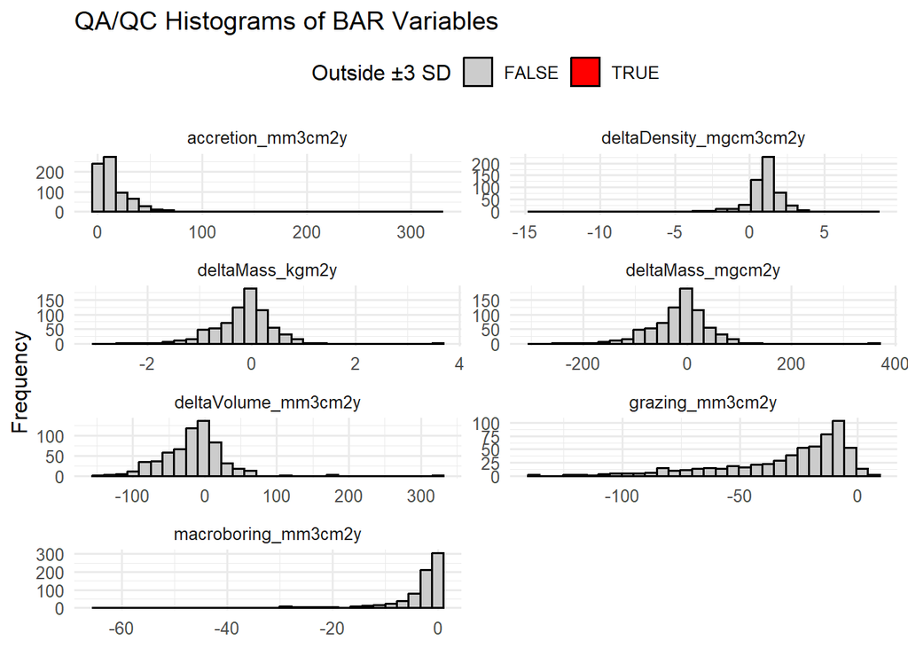

Values Outside ±3 SD (by variable)

| Bar tag | deltaMass_mgcm2y | deltaMass_kgm2y | deltaVolume_mm3cm2y | deltaDensity_mgcm3cm2y | macroboring_mm3cm2y | accretion_mm3cm2y | grazing_mm3cm2y |
| --- | --- | --- | --- | --- | --- | --- | --- |
| 1015 |  |  |  | NA | -24.8938777859082 |  |  |
| 1036 | -245.834828018896 | -2.45834828018896 | NA | NA | NA | NA | NA |
| 1049 | -200.023335509138 | -2.00023335509138 | NA | NA | NA | NA | NA |
| 1056 | -256.878625541125 | -2.56878625541126 | NA | NA | NA | NA | NA |
| 1057 | -211.419762529138 | -2.11419762529138 | NA | NA | NA | NA | NA |
| 1062 | -222.518185495734 | -2.22518185495734 | NA | NA | NA | NA | NA |
| 1070 | -203.688888888889 | -2.03688888888889 | NA | NA | NA | NA | NA |
| 1071 | -295.372461642599 | -2.95372461642599 | NA | NA | NA | NA | NA |
| 1075 | -252.639384920635 | -2.52639384920635 | NA | NA | NA | NA | NA |
| 1077 | -234.751094504831 | -2.34751094504831 | NA | NA | NA | NA | NA |
| 1078 |  |  |  | NA |  | 100.401735636086 |  |
| 1089 | 349.434480122324 | 3.49434480122324 | 323.694505156728 | NA |  | 325.552189818425 |  |
| 1090 |  |  |  | NA |  | 104.784407358433 |  |
| 1091 | 204.908263630731 | 2.04908263630731 | 179.12630353005 | NA |  | 211.158554923714 |  |
| 1099 | 358.255125506704 | 3.58255125506704 | 185.217165931946 | NA |  | 186.773089969208 |  |
| 1202 |  |  |  |  |  |  | -111.780156371243 |
| 1307 |  |  |  |  | -24.5193132628601 |  |  |
| 1601 | NA, NA | NA, NA | NA, NA | NA, NA | NA, NA | NA, NA | NA, NA |
| 1604 | NA, NA | NA, NA | NA, NA | NA, NA | NA, NA | NA, NA | NA, NA |
| 1605 | NA, NA | NA, NA | NA, NA | NA, NA | NA, NA | NA, NA | NA, NA |
| 1607 | NA, NA | NA, NA | NA, NA | NA, NA | NA, NA | NA, NA | NA, NA |
| 1609 | NA, NA | NA, NA | NA, NA | NA, NA | NA, NA | NA, NA | NA, NA |
| 1611 | NA, NA | NA, NA | NA, NA | NA, NA | NA, NA | NA, NA | NA, NA |
| 1612 | NA, NA | NA, NA | NA, NA | NA, NA | NA, NA | NA, NA | NA, NA |
| 1613 | NA, NA | NA, NA | NA, NA | NA, NA | NA, NA | NA, NA | NA, NA |
| 1614 | NA, NA | NA, NA | NA, NA | NA, NA | NA, NA | NA, NA | NA, NA |
| 1615 | NA, NA | NA, NA | NA, NA | NA, NA | NA, NA | NA, NA | NA, NA |
| 1616 | NA, NA | NA, NA | NA, NA | NA, NA | NA, NA | NA, NA | NA, NA |
| 1617 | NA, NA | NA, NA | NA, NA | NA, NA | NA, NA | NA, NA | NA, NA |
| 1618 | NA, NA | NA, NA | NA, NA | NA, NA | NA, NA | NA, NA | NA, NA |

[output cut: 57 more lines]

```
## Bars to remove due to ±3 SD outliers: 87
```

### 1.0.12 Graph deployment duration

### 1.0.13 Clean data

Remove data that is 1. Not successfully recovered 2. Not plob or mcav 3. Tag 1022 4. Data from Maug seep 5. Grazing data that is positive 6. Deployed for more than 6 years or less than 2 years 7. Depth is less than 10m

### 1.0.14 Remove vars with low replication

```
## ### Values masked (set to NA) where loc3 has < 3 non-NA measurements (per variable)
```

| var | n_locs_total | n_locs_below_min |
| --- | --- | --- |
| deltaMass_mgcm2y | 64 | 6 |
| deltaMass_kgm2y | 64 | 6 |
| deltaVolume_mm3cm2y | 64 | 15 |
| deltaDensity_mgcm3cm2y | 64 | 21 |
| macroboring_mm3cm2y | 64 | 6 |
| accretion_mm3cm2y | 64 | 6 |
| grazing_mm3cm2y | 64 | 15 |

### 1.0.15 Remove rows that have NA’s for all vars

### 1.0.16 Check binds across datasets

loc1 Comparison: BAR vs PARROT vs ENV

| loc1 | in_BAR | in_PARROT | in_ENV | match_status |
| --- | --- | --- | --- | --- |
| caribbean | TRUE | TRUE | TRUE | MATCH |
| florida | TRUE | TRUE | TRUE | MATCH |
| flowerGardenBanks | TRUE | TRUE | TRUE | MATCH |
| marianas | TRUE | TRUE | TRUE | MATCH |
| middleHawaiianIslands | TRUE | TRUE | TRUE | MATCH |
| northwestHawaiianIslands | TRUE | TRUE | TRUE | MATCH |
| pacificRemoteIslandArea | TRUE | TRUE | TRUE | MATCH |
| samoa | TRUE | TRUE | TRUE | MATCH |

loc2 Comparison: BAR vs PARROT vs ENV

| loc2 | in_BAR | in_PARROT | in_ENV | match_status |
| --- | --- | --- | --- | --- |
| dryTortugas | TRUE | TRUE | TRUE | MATCH |
| flowerGardenBanks | TRUE | TRUE | TRUE | MATCH |
| frenchFrigateShoals | FALSE | TRUE | TRUE | PARROT & ENV only |
| guam | TRUE | TRUE | TRUE | MATCH |
| hawaii | TRUE | TRUE | TRUE | MATCH |
| jarvis | TRUE | TRUE | TRUE | MATCH |
| keys | TRUE | TRUE | TRUE | MATCH |
| maug | TRUE | TRUE | TRUE | MATCH |
| oahu | TRUE | TRUE | TRUE | MATCH |
| ofu | TRUE | TRUE | TRUE | MATCH |
| pagan | TRUE | TRUE | TRUE | MATCH |
| palmyra | TRUE | TRUE | TRUE | MATCH |
| pearlHermes | TRUE | TRUE | TRUE | MATCH |
| puertoRico | TRUE | TRUE | TRUE | MATCH |
| saintCroix | TRUE | TRUE | TRUE | MATCH |
| saintJohn | TRUE | TRUE | TRUE | MATCH |
| saintThomas | TRUE | TRUE | TRUE | MATCH |
| saipan | TRUE | TRUE | TRUE | MATCH |
| tau | TRUE | TRUE | TRUE | MATCH |
| tutuila | TRUE | TRUE | TRUE | MATCH |
| wake | TRUE | TRUE | TRUE | MATCH |

loc3 Comparison: BAR vs PARROT vs ENV

| loc3 | in_BAR | in_PARROT | in_ENV | match_status |
| --- | --- | --- | --- | --- |
| dryTortugas-west | TRUE | TRUE | TRUE | MATCH |
| flowerGardenBanks-east | TRUE | TRUE | TRUE | MATCH |
| frenchFrigateShoals-east | FALSE | TRUE | TRUE | PARROT & ENV only |
| frenchFrigateShoals-north | FALSE | TRUE | TRUE | PARROT & ENV only |
| frenchFrigateShoals-south | FALSE | TRUE | TRUE | PARROT & ENV only |
| frenchFrigateShoals-west | FALSE | TRUE | TRUE | PARROT & ENV only |
| guam-east | TRUE | TRUE | TRUE | MATCH |
| guam-north | TRUE | TRUE | TRUE | MATCH |
| guam-south | TRUE | TRUE | TRUE | MATCH |
| guam-west | TRUE | TRUE | TRUE | MATCH |
| hawaii-east | FALSE | TRUE | TRUE | PARROT & ENV only |
| hawaii-north | TRUE | TRUE | TRUE | MATCH |
| hawaii-northExtra | FALSE | FALSE | TRUE | ONLY in ENV |
| hawaii-south | FALSE | TRUE | TRUE | PARROT & ENV only |
| hawaii-west | TRUE | TRUE | TRUE | MATCH |
| jarvis-east | FALSE | TRUE | FALSE | ONLY in PARROT |
| jarvis-south | TRUE | TRUE | TRUE | MATCH |
| jarvis-west | TRUE | TRUE | TRUE | MATCH |
| keys-lki | FALSE | TRUE | TRUE | PARROT & ENV only |
| keys-lko | FALSE | TRUE | TRUE | PARROT & ENV only |
| keys-mki | FALSE | TRUE | TRUE | PARROT & ENV only |
| keys-mko | FALSE | TRUE | TRUE | PARROT & ENV only |
| keys-uki | FALSE | TRUE | TRUE | PARROT & ENV only |
| keys-uko | TRUE | TRUE | TRUE | MATCH |
| keys-uko1 | FALSE | FALSE | TRUE | ONLY in ENV |
| maug-east | TRUE | TRUE | TRUE | MATCH |
| maug-innerHCO2 | FALSE | TRUE | TRUE | PARROT & ENV only |
| maug-innerMCO2 | FALSE | TRUE | TRUE | PARROT & ENV only |
| maug-north | TRUE | TRUE | TRUE | MATCH |
| maug-south | TRUE | TRUE | TRUE | MATCH |

[output cut: 53 more lines]

### 1.0.17 Removes Env and Parrot data if parrot and env only, or only in env, or only parrot

```
## Removing loc3 missing from BAR: 25
```

### 1.0.18 Check binds across datasets again after removal

loc1 Comparison: BAR vs PARROT vs ENV

| loc1 | in_BAR | in_PARROT | in_ENV | match_status |
| --- | --- | --- | --- | --- |
| caribbean | TRUE | TRUE | TRUE | MATCH |
| florida | TRUE | TRUE | TRUE | MATCH |
| flowerGardenBanks | TRUE | TRUE | TRUE | MATCH |
| marianas | TRUE | TRUE | TRUE | MATCH |
| middleHawaiianIslands | TRUE | TRUE | TRUE | MATCH |
| northwestHawaiianIslands | TRUE | TRUE | TRUE | MATCH |
| pacificRemoteIslandArea | TRUE | TRUE | TRUE | MATCH |
| samoa | TRUE | TRUE | TRUE | MATCH |

loc2 Comparison: BAR vs PARROT vs ENV

| loc2 | in_BAR | in_PARROT | in_ENV | match_status |
| --- | --- | --- | --- | --- |
| dryTortugas | TRUE | TRUE | TRUE | MATCH |
| flowerGardenBanks | TRUE | TRUE | TRUE | MATCH |
| guam | TRUE | TRUE | TRUE | MATCH |
| hawaii | TRUE | TRUE | TRUE | MATCH |
| jarvis | TRUE | TRUE | TRUE | MATCH |
| keys | TRUE | TRUE | TRUE | MATCH |
| maug | TRUE | TRUE | TRUE | MATCH |
| oahu | TRUE | TRUE | TRUE | MATCH |
| ofu | TRUE | TRUE | TRUE | MATCH |
| pagan | TRUE | TRUE | TRUE | MATCH |
| palmyra | TRUE | TRUE | TRUE | MATCH |
| pearlHermes | TRUE | TRUE | TRUE | MATCH |
| puertoRico | TRUE | TRUE | TRUE | MATCH |
| saintCroix | TRUE | TRUE | TRUE | MATCH |
| saintJohn | TRUE | TRUE | TRUE | MATCH |
| saintThomas | TRUE | TRUE | TRUE | MATCH |
| saipan | TRUE | TRUE | TRUE | MATCH |
| tau | TRUE | TRUE | TRUE | MATCH |
| tutuila | TRUE | TRUE | TRUE | MATCH |
| wake | TRUE | TRUE | TRUE | MATCH |

loc3 Comparison: BAR vs PARROT vs ENV

| loc3 | in_BAR | in_PARROT | in_ENV | match_status |
| --- | --- | --- | --- | --- |
| dryTortugas-west | TRUE | TRUE | TRUE | MATCH |
| flowerGardenBanks-east | TRUE | TRUE | TRUE | MATCH |
| guam-east | TRUE | TRUE | TRUE | MATCH |
| guam-north | TRUE | TRUE | TRUE | MATCH |
| guam-south | TRUE | TRUE | TRUE | MATCH |
| guam-west | TRUE | TRUE | TRUE | MATCH |
| hawaii-north | TRUE | TRUE | TRUE | MATCH |
| hawaii-west | TRUE | TRUE | TRUE | MATCH |
| jarvis-south | TRUE | TRUE | TRUE | MATCH |
| jarvis-west | TRUE | TRUE | TRUE | MATCH |
| keys-uko | TRUE | TRUE | TRUE | MATCH |
| maug-east | TRUE | TRUE | TRUE | MATCH |
| maug-north | TRUE | TRUE | TRUE | MATCH |
| maug-south | TRUE | TRUE | TRUE | MATCH |
| maug-west | TRUE | TRUE | TRUE | MATCH |
| oahu-east | TRUE | TRUE | TRUE | MATCH |
| oahu-north | TRUE | TRUE | FALSE | BAR & PARROT only |
| oahu-south | TRUE | TRUE | TRUE | MATCH |
| oahu-west | TRUE | TRUE | TRUE | MATCH |
| ofu-north | TRUE | TRUE | TRUE | MATCH |
| ofu-south | TRUE | TRUE | TRUE | MATCH |
| pagan-east | TRUE | TRUE | TRUE | MATCH |
| pagan-north | TRUE | TRUE | TRUE | MATCH |
| pagan-south | TRUE | TRUE | TRUE | MATCH |
| pagan-west | TRUE | TRUE | TRUE | MATCH |
| palmyra-east | TRUE | TRUE | TRUE | MATCH |
| palmyra-north | TRUE | TRUE | TRUE | MATCH |
| palmyra-west | TRUE | TRUE | TRUE | MATCH |
| pearlHermes-south | TRUE | TRUE | TRUE | MATCH |
| pearlHermes-west | TRUE | TRUE | FALSE | BAR & PARROT only |
| puertoRico-east | TRUE | TRUE | TRUE | MATCH |
| puertoRico-north | TRUE | TRUE | TRUE | MATCH |
| puertoRico-northeast | TRUE | TRUE | TRUE | MATCH |
| puertoRico-south | TRUE | TRUE | TRUE | MATCH |
| puertoRico-west | TRUE | TRUE | TRUE | MATCH |
| saintCroix-east | TRUE | TRUE | TRUE | MATCH |
| saintCroix-north | TRUE | TRUE | TRUE | MATCH |
| saintCroix-south | TRUE | TRUE | TRUE | MATCH |
| saintCroix-west | TRUE | TRUE | TRUE | MATCH |
| saintJohn-north | TRUE | TRUE | TRUE | MATCH |
| saintJohn-south | TRUE | TRUE | TRUE | MATCH |
| saintJohn-west | TRUE | TRUE | TRUE | MATCH |
| saintThomas-north | TRUE | TRUE | TRUE | MATCH |
| saintThomas-south | TRUE | TRUE | TRUE | MATCH |
| saintThomas-west | TRUE | TRUE | TRUE | MATCH |
| saipan-east | TRUE | TRUE | TRUE | MATCH |
| saipan-northwest | TRUE | TRUE | TRUE | MATCH |
| saipan-south | TRUE | TRUE | TRUE | MATCH |
| saipan-west | TRUE | TRUE | TRUE | MATCH |
| tau-north | TRUE | TRUE | TRUE | MATCH |
| tau-west | TRUE | TRUE | TRUE | MATCH |
| tutuila-east | TRUE | TRUE | TRUE | MATCH |
| tutuila-north | TRUE | TRUE | TRUE | MATCH |
| tutuila-south | TRUE | TRUE | TRUE | MATCH |
| tutuila-west | TRUE | TRUE | TRUE | MATCH |
| wake-north | TRUE | TRUE | TRUE | MATCH |
| wake-south | TRUE | TRUE | TRUE | MATCH |
| wake-west | TRUE | TRUE | TRUE | MATCH |

### 1.0.19 Count numbers of replicates of each variable by loc2 and loc3

Non-missing counts by loc2 (per variable)

| loc2 | n_rows | deltaMass_mgcm2y | deltaMass_kgm2y | deltaVolume_mm3cm2y | deltaDensity_mgcm3cm2y | macroboring_mm3cm2y | accretion_mm3cm2y | grazing_mm3cm2y |
| --- | --- | --- | --- | --- | --- | --- | --- | --- |
| saintCroix | 59 | 59 | 59 | 59 | 54 | 59 | 59 | 59 |
| maug | 37 | 37 | 37 | 37 | 26 | 37 | 37 | 37 |
| keys | 35 | 35 | 35 | 35 | 35 | 35 | 35 | 35 |
| pagan | 32 | 32 | 32 | 31 | 17 | 32 | 32 | 31 |
| oahu | 24 | 24 | 24 | 24 | 24 | 24 | 24 | 24 |
| puertoRico | 23 | 23 | 23 | 13 | 13 | 23 | 23 | 13 |
| saipan | 23 | 23 | 23 | 23 | 8 | 23 | 23 | 23 |
| guam | 21 | 21 | 21 | 21 | 13 | 21 | 21 | 21 |
| hawaii | 21 | 21 | 21 | 21 | 21 | 21 | 21 | 21 |
| tutuila | 19 | 19 | 19 | 19 | 19 | 19 | 19 | 19 |
| dryTortugas | 18 | 18 | 18 | 18 | 18 | 18 | 18 | 18 |
| pearlHermes | 18 | 18 | 18 | 18 | 18 | 18 | 18 | 18 |
| saintThomas | 13 | 13 | 13 | 0 | 0 | 13 | 13 | 0 |
| flowerGardenBanks | 12 | 12 | 12 | 12 | 12 | 10 | 12 | 10 |
| saintJohn | 12 | 12 | 12 | 0 | 0 | 12 | 12 | 0 |
| palmyra | 11 | 11 | 11 | 10 | 10 | 11 | 11 | 10 |
| wake | 10 | 10 | 10 | 10 | 0 | 10 | 10 | 10 |
| tau | 8 | 8 | 8 | 7 | 7 | 8 | 8 | 7 |
| ofu | 7 | 7 | 7 | 7 | 7 | 7 | 7 | 7 |
| jarvis | 6 | 6 | 6 | 3 | 3 | 6 | 6 | 3 |
| TOTAL | 409 | 409 | 409 | 368 | 305 | 407 | 409 | 366 |

Non-missing counts by loc3 (per variable)

| loc3 | n_rows | deltaMass_mgcm2y | deltaMass_kgm2y | deltaVolume_mm3cm2y | deltaDensity_mgcm3cm2y | macroboring_mm3cm2y | accretion_mm3cm2y | grazing_mm3cm2y |
| --- | --- | --- | --- | --- | --- | --- | --- | --- |
| keys-uko | 35 | 35 | 35 | 35 | 35 | 35 | 35 | 35 |
| saintCroix-north | 19 | 19 | 19 | 19 | 14 | 19 | 19 | 19 |
| dryTortugas-west | 18 | 18 | 18 | 18 | 18 | 18 | 18 | 18 |
| maug-south | 15 | 15 | 15 | 15 | 15 | 15 | 15 | 15 |
| saintCroix-west | 15 | 15 | 15 | 15 | 15 | 15 | 15 | 15 |
| saintCroix-east | 14 | 14 | 14 | 14 | 14 | 14 | 14 | 14 |
| hawaii-north | 13 | 13 | 13 | 13 | 13 | 13 | 13 | 13 |
| flowerGardenBanks-east | 12 | 12 | 12 | 12 | 12 | 10 | 12 | 10 |
| saintCroix-south | 11 | 11 | 11 | 11 | 11 | 11 | 11 | 11 |
| pagan-south | 10 | 10 | 10 | 10 | 5 | 10 | 10 | 10 |
| pagan-west | 10 | 10 | 10 | 10 | 5 | 10 | 10 | 10 |
| maug-north | 9 | 9 | 9 | 9 | 5 | 9 | 9 | 9 |
| pearlHermes-south | 9 | 9 | 9 | 9 | 9 | 9 | 9 | 9 |
| pearlHermes-west | 9 | 9 | 9 | 9 | 9 | 9 | 9 | 9 |
| guam-south | 8 | 8 | 8 | 8 | 5 | 8 | 8 | 8 |
| hawaii-west | 8 | 8 | 8 | 8 | 8 | 8 | 8 | 8 |
| maug-west | 8 | 8 | 8 | 8 | 3 | 8 | 8 | 8 |
| oahu-east | 8 | 8 | 8 | 8 | 8 | 8 | 8 | 8 |
| pagan-north | 8 | 8 | 8 | 7 | 3 | 8 | 8 | 7 |
| saipan-east | 8 | 8 | 8 | 8 | 5 | 8 | 8 | 8 |
| oahu-south | 7 | 7 | 7 | 7 | 7 | 7 | 7 | 7 |
| guam-east | 6 | 6 | 6 | 6 | 4 | 6 | 6 | 6 |
| oahu-west | 6 | 6 | 6 | 6 | 6 | 6 | 6 | 6 |
| saintThomas-south | 6 | 6 | 6 | 0 | 0 | 6 | 6 | 0 |
| saipan-south | 6 | 6 | 6 | 6 | 0 | 6 | 6 | 6 |
| saipan-west | 6 | 6 | 6 | 6 | 0 | 6 | 6 | 6 |
| maug-east | 5 | 5 | 5 | 5 | 3 | 5 | 5 | 5 |
| puertoRico-east | 5 | 5 | 5 | 0 | 0 | 5 | 5 | 0 |
| puertoRico-northeast | 5 | 5 | 5 | 0 | 0 | 5 | 5 | 0 |
| puertoRico-west | 5 | 5 | 5 | 5 | 5 | 5 | 5 | 5 |
| saintJohn-south | 5 | 5 | 5 | 0 | 0 | 5 | 5 | 0 |
| tutuila-east | 5 | 5 | 5 | 5 | 5 | 5 | 5 | 5 |
| tutuila-south | 5 | 5 | 5 | 5 | 5 | 5 | 5 | 5 |
| tutuila-west | 5 | 5 | 5 | 5 | 5 | 5 | 5 | 5 |
| guam-north | 4 | 4 | 4 | 4 | 4 | 4 | 4 | 4 |
| ofu-north | 4 | 4 | 4 | 4 | 4 | 4 | 4 | 4 |
| pagan-east | 4 | 4 | 4 | 4 | 4 | 4 | 4 | 4 |
| palmyra-east | 4 | 4 | 4 | 3 | 3 | 4 | 4 | 3 |
| palmyra-north | 4 | 4 | 4 | 4 | 4 | 4 | 4 | 4 |
| puertoRico-north | 4 | 4 | 4 | 4 | 4 | 4 | 4 | 4 |
| puertoRico-south | 4 | 4 | 4 | 4 | 4 | 4 | 4 | 4 |
| saintJohn-north | 4 | 4 | 4 | 0 | 0 | 4 | 4 | 0 |
| saintThomas-north | 4 | 4 | 4 | 0 | 0 | 4 | 4 | 0 |
| tau-north | 4 | 4 | 4 | 3 | 3 | 4 | 4 | 3 |
| tau-west | 4 | 4 | 4 | 4 | 4 | 4 | 4 | 4 |
| tutuila-north | 4 | 4 | 4 | 4 | 4 | 4 | 4 | 4 |
| wake-north | 4 | 4 | 4 | 4 | 0 | 4 | 4 | 4 |
| guam-west | 3 | 3 | 3 | 3 | 0 | 3 | 3 | 3 |
| jarvis-south | 3 | 3 | 3 | 0 | 0 | 3 | 3 | 0 |
| jarvis-west | 3 | 3 | 3 | 3 | 3 | 3 | 3 | 3 |
| oahu-north | 3 | 3 | 3 | 3 | 3 | 3 | 3 | 3 |
| ofu-south | 3 | 3 | 3 | 3 | 3 | 3 | 3 | 3 |
| palmyra-west | 3 | 3 | 3 | 3 | 3 | 3 | 3 | 3 |
| saintJohn-west | 3 | 3 | 3 | 0 | 0 | 3 | 3 | 0 |
| saintThomas-west | 3 | 3 | 3 | 0 | 0 | 3 | 3 | 0 |
| saipan-northwest | 3 | 3 | 3 | 3 | 3 | 3 | 3 | 3 |
| wake-south | 3 | 3 | 3 | 3 | 0 | 3 | 3 | 3 |
| wake-west | 3 | 3 | 3 | 3 | 0 | 3 | 3 | 3 |
| TOTAL | 409 | 409 | 409 | 368 | 305 | 407 | 409 | 366 |

# 2 Data exploration

## 2.1 General

### 2.1.1 Map of BAR, parrot surveys, and environmental sites

[interactive chart not shown]

### 2.1.2 Timeline of BAR data, parrot surveys, and environmental data

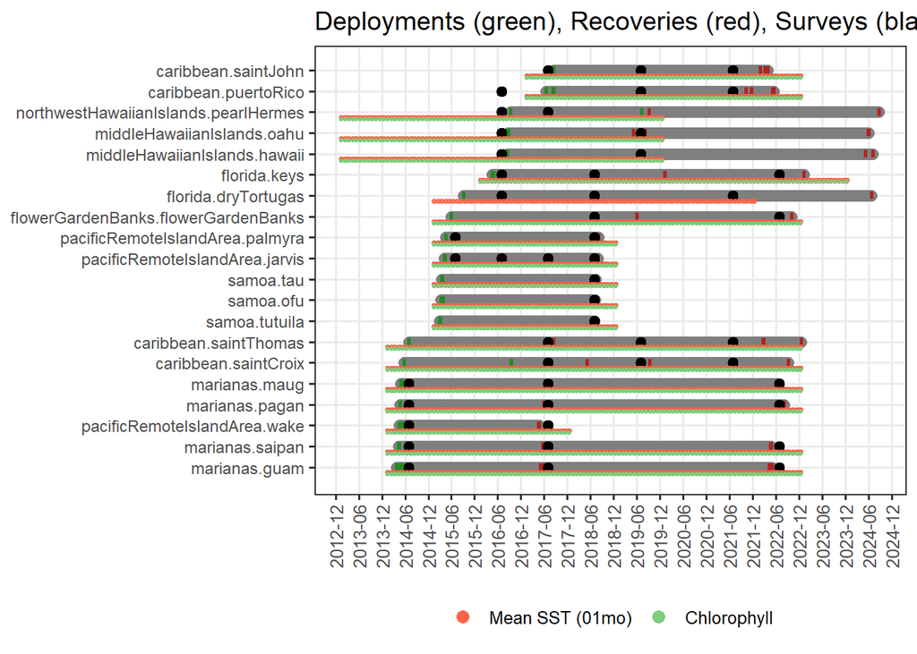

## 2.2 BAR data

### 2.2.1 Summary of locations and durations

Sites are divided at three levels across 2 basins. The highest level (loc1) includes 8 large regions including:  
caribbean, flowerGardenBanks, florida, marianas, middleHawaiianIslands, pacificRemoteIslandArea, samoa, northwestHawaiianIslands

Within these larger regions are 20 sublevels (loc2) that are generally inclusive of an island including:  
saintCroix, saintThomas, flowerGardenBanks, dryTortugas, keys, puertoRico, saintJohn, guam, hawaii, jarvis, maug, oahu, ofu, pagan, palmyra, pearlHermes, saipan, tau, tutuila, wake

Most islands or loc2 level includes multiple sites (loc3) within it, totaling 58 loc3 levels across both basins

Deployment dates ranged from 2014-03-25 to 2021-06-26 and recovery dates ranged from 2017-04-19 to 2024-08-24. The deployment duration ranged from 993 to 1950 days and was on 1381.5305623 days.

### 2.2.2 Calculation of stats for bar alteration by loc2

| location basin | location loc1 | location loc2 | location loc1.2 | duration maxDays | duration minDays | duration n | depth maxDepth | depth minDepth | depth meanDepth | deltaMass_mgcm2yr meanDeltaMass_mgcm2y | deltaMass_mgcm2yr countDeltaMass_mgcm2y | deltaMass_mgcm2yr sdDeltaMass_mgcm2y | deltaMass_mgcm2yr seDeltaMass_mgcm2y | deltaMass_kgm2y meanDeltaMass_kgm2y | deltaMass_kgm2y countDeltaMass_kgm2y | deltaMass_kgm2y sdDeltaMass_kgm2y | deltaMass_kgm2y seDeltaMass_kgm2y | deltaVolume meanDeltaVolume | deltaVolume countDeltaVolume | deltaVolume sdDeltaVolume | deltaVolume seDeltaVolume | deltaDensity meanDeltaDensity | deltaDensity countDeltaDensity | deltaDensity sdDeltaDensity | deltaDensity seDeltaDensity | macroboring meanMacroboring | macroboring countMacroboring | macroboring sdMacroboring | macroboring seMacroboring | … |
| --- | --- | --- | --- | --- | --- | --- | --- | --- | --- | --- | --- | --- | --- | --- | --- | --- | --- | --- | --- | --- | --- | --- | --- | --- | --- | --- | --- | --- | --- | --- |
| atlantic | caribbean | puertoRico | caribbean.puertoRico | 1798 | 1573 | 23 | 16.1 | 13.0 | 14.91304 | -13.448923 | 23 | 29.502368 | 6.151669 | -0.1344892 | 23 | 0.2950237 | 0.0615167 | -10.782447 | 13 | 14.159847 | 3.927235 | 1.1061227 | 13 | 0.5320711 | 0.1475700 | -6.3528859 | 23 | 5.3297098 | 1.1113213 | … |
| atlantic | caribbean | saintCroix | caribbean.saintCroix | 1441 | 1090 | 59 | 17.0 | 14.6 | 16.24915 | -9.148334 | 59 | 28.583683 | 3.721279 | -0.0914833 | 59 | 0.2858368 | 0.0372128 | -17.442065 | 59 | 24.135804 | 3.142214 | 0.9913609 | 54 | 0.8232730 | 0.1120333 | -3.8274967 | 59 | 3.3519761 | 0.4363901 | … |
| atlantic | caribbean | saintJohn | caribbean.saintJohn | 1686 | 1632 | 12 | 16.7 | 15.2 | 15.92500 | -29.024773 | 12 | 35.636340 | 10.287325 | -0.2902477 | 12 | 0.3563634 | 0.1028733 | NaN | 0 | NA | NA | NaN | 0 | NA | NA | -7.1319396 | 12 | 3.9029046 | 1.1266715 | … |
| atlantic | caribbean | saintThomas | caribbean.saintThomas | 1950 | 1142 | 13 | 16.7 | 15.5 | 16.05385 | -32.971049 | 13 | 35.340282 | 9.801631 | -0.3297105 | 13 | 0.3534028 | 0.0980163 | NaN | 0 | NA | NA | NaN | 0 | NA | NA | -4.0740055 | 13 | 3.2882413 | 0.9119941 | … |
| atlantic | florida | dryTortugas | florida.dryTortugas | 1093 | 1043 | 18 | 15.2 | 15.2 | 15.20000 | -16.804326 | 18 | 29.778896 | 7.018953 | -0.1680433 | 18 | 0.2977890 | 0.0701895 | -22.812553 | 18 | 24.159547 | 5.694460 | 0.5576937 | 18 | 1.7098776 | 0.4030220 | -6.6204479 | 18 | 6.8886331 | 1.6236664 | … |
| atlantic | florida | keys | florida.keys | 1358 | 1100 | 35 | 12.5 | 12.5 | 12.50000 | 8.533807 | 35 | 25.423593 | 4.297372 | 0.0853381 | 35 | 0.2542359 | 0.0429737 | -7.012415 | 35 | 19.940548 | 3.370568 | 1.2660919 | 35 | 0.5830175 | 0.0985479 | -2.9450028 | 35 | 3.0297685 | 0.5121243 | … |
| atlantic | flowerGardenBanks | flowerGardenBanks | flowerGardenBanks.flowerGardenBanks | 1463 | 1220 | 12 | 20.7 | 20.7 | 20.70000 | -72.298636 | 12 | 36.395673 | 10.506526 | -0.7229864 | 12 | 0.3639567 | 0.1050653 | -63.174703 | 12 | 25.518208 | 7.366472 | 1.6656771 | 12 | 2.0959348 | 0.6050442 | -0.8068248 | 10 | 1.2321116 | 0.3896279 | … |
| pacific | marianas | guam | marianas.guam | 1813 | 1085 | 21 | 16.5 | 13.7 | 14.92857 | -18.707283 | 21 | 57.737344 | 12.599322 | -0.1870728 | 21 | 0.5773734 | 0.1259932 | -22.064378 | 21 | 44.106267 | 9.624776 | 1.4989461 | 13 | 0.7874475 | 0.2183986 | -1.4861805 | 21 | 2.2322344 | 0.4871135 | … |
| pacific | marianas | maug | marianas.maug | 1840 | 1133 | 37 | 16.2 | 10.4 | 13.06486 | -20.329619 | 37 | 43.155854 | 7.094779 | -0.2032962 | 37 | 0.4315585 | 0.0709478 | -26.317644 | 37 | 37.678857 | 6.194366 | 1.0373989 | 26 | 0.4025262 | 0.0789419 | -0.8864777 | 37 | 0.6903796 | 0.1134977 | … |
| pacific | marianas | pagan | marianas.pagan | 1879 | 1136 | 32 | 17.4 | 14.6 | 15.86875 | -3.290765 | 32 | 33.784461 | 5.972305 | -0.0329076 | 32 | 0.3378446 | 0.0597231 | -10.089571 | 31 | 29.580337 | 5.312785 | 1.0495521 | 17 | 0.5617518 | 0.1362448 | -2.9544263 | 32 | 4.6997275 | 0.8308023 | … |
| pacific | marianas | saipan | marianas.saipan | 1800 | 1127 | 23 | 17.4 | 12.5 | 15.36522 | -50.308038 | 23 | 47.257391 | 9.853847 | -0.5030804 | 23 | 0.4725739 | 0.0985385 | -47.155204 | 23 | 36.709960 | 7.654556 | 1.5421262 | 8 | 0.6305356 | 0.2229280 | -0.8146666 | 23 | 1.0867265 | 0.2265981 | … |
| pacific | middleHawaiianIslands | hawaii | middleHawaiianIslands.hawaii | 1818 | 1064 | 21 | 14.3 | 13.7 | 14.07143 | -18.872941 | 21 | 28.483093 | 6.215520 | -0.1887294 | 21 | 0.2848309 | 0.0621552 | -19.061123 | 21 | 22.776074 | 4.970147 | 1.2084105 | 21 | 0.6451226 | 0.1407773 | -5.7729464 | 21 | 7.2448232 | 1.5809500 | … |
| pacific | middleHawaiianIslands | oahu | middleHawaiianIslands.oahu | 1849 | 993 | 24 | 14.6 | 12.2 | 13.12500 | -26.317597 | 24 | 37.402414 | 7.634736 | -0.2631760 | 24 | 0.3740241 | 0.0763474 | -23.561269 | 24 | 29.599674 | 6.042008 | 1.0863930 | 24 | 1.0448180 | 0.2132726 | -4.6085134 | 24 | 5.3117772 | 1.0842620 | … |
| pacific | northwestHawaiianIslands | pearlHermes | northwestHawaiianIslands.pearlHermes | 1870 | 1088 | 18 | 13.7 | 13.7 | 13.70000 | -4.590498 | 18 | 8.488513 | 2.000762 | -0.0459050 | 18 | 0.0848851 | 0.0200076 | -7.711617 | 18 | 5.267356 | 1.241528 | 1.0012966 | 18 | 0.1901713 | 0.0448238 | -0.7394912 | 18 | 1.8347163 | 0.4324468 | … |
| pacific | pacificRemoteIslandArea | jarvis | pacificRemoteIslandArea.jarvis | 1210 | 1205 | 6 | 14.9 | 14.6 | 14.75000 | -47.427541 | 6 | 33.963475 | 13.865531 | -0.4742754 | 6 | 0.3396347 | 0.1386553 | -47.319912 | 3 | 16.887102 | 9.749773 | 0.2872554 | 3 | 1.3118399 | 0.7573911 | -2.0451382 | 6 | 0.5520917 | 0.2253905 | … |
| pacific | pacificRemoteIslandArea | palmyra | pacificRemoteIslandArea.palmyra | 1207 | 1202 | 11 | 14.9 | 13.4 | 14.24545 | -49.808010 | 11 | 59.341665 | 17.892185 | -0.4980801 | 11 | 0.5934167 | 0.1789219 | -40.143502 | 10 | 45.318649 | 14.331015 | 0.6662410 | 10 | 0.8372087 | 0.2647486 | -0.3924558 | 11 | 1.0214884 | 0.3079903 | … |
| pacific | pacificRemoteIslandArea | wake | pacificRemoteIslandArea.wake | 1099 | 1063 | 10 | 15.2 | 13.4 | 13.94000 | -81.367707 | 10 | 49.240408 | 15.571184 | -0.8136771 | 10 | 0.4924041 | 0.1557118 | -58.140210 | 10 | 36.194231 | 11.445621 | NaN | 0 | NA | NA | -0.7715009 | 10 | 1.0972455 | 0.3469795 | … |
| pacific | samoa | ofu | samoa.ofu | 1214 | 1199 | 7 | 14.6 | 14.6 | 14.60000 | 6.382131 | 7 | 48.624755 | 18.378430 | 0.0638213 | 7 | 0.4862476 | 0.1837843 | 4.680463 | 7 | 29.713490 | 11.230643 | -0.5377108 | 7 | 0.8564338 | 0.3237016 | -5.9346301 | 7 | 6.8481269 | 2.5883487 | … |
| pacific | samoa | tau | samoa.tau | 1215 | 1206 | 8 | 14.9 | 14.3 | 14.60000 | 41.568708 | 8 | 34.003000 | 12.021876 | 0.4156871 | 8 | 0.3400300 | 0.1202188 | 34.590746 | 7 | 24.903534 | 9.412651 | 0.0392026 | 7 | 1.5035917 | 0.5683042 | -2.6640838 | 8 | 3.6276438 | 1.2825658 | … |
| pacific | samoa | tutuila | samoa.tutuila | 1223 | 1216 | 19 | 15.8 | 13.7 | 14.60000 | 15.614836 | 19 | 51.926517 | 11.912760 | 0.1561484 | 19 | 0.5192652 | 0.1191276 | 3.532612 | 19 | 36.708065 | 8.421408 | -0.5591948 | 19 | 1.3716151 | 0.3146701 | -3.1631227 | 19 | 2.9894899 | 0.6858360 | … |

### 2.2.3 Calculation of stats for bar alteration by loc3

| location basin | location loc1 | location loc2 | location loc1.2 | duration loc3 | duration maxDays | duration minDays | depth maxDepth | depth minDepth | depth meanDepth | deltaMass_mgcm2yr meanDeltaMass_mgcm2y | deltaMass_mgcm2yr countDeltaMass_mgcm2y | deltaMass_mgcm2yr sdDeltaMass_mgcm2y | deltaMass_mgcm2yr seDeltaMass_mgcm2y | deltaMass_kgm2y meanDeltaMass_kgm2y | deltaMass_kgm2y countDeltaMass_kgm2y | deltaMass_kgm2y sdDeltaMass_kgm2y | deltaMass_kgm2y seDeltaMass_kgm2y | deltaVolume meanDeltaVolume | deltaVolume countDeltaVolume | deltaVolume sdDeltaVolume | deltaVolume seDeltaVolume | deltaDensity meanDeltaDensity | deltaDensity countDeltaDensity | deltaDensity sdDeltaDensity | deltaDensity seDeltaDensity | macroboring meanMacroboring | macroboring countMacroboring | macroboring sdMacroboring | macroboring seMacroboring | … |
| --- | --- | --- | --- | --- | --- | --- | --- | --- | --- | --- | --- | --- | --- | --- | --- | --- | --- | --- | --- | --- | --- | --- | --- | --- | --- | --- | --- | --- | --- | --- |
| atlantic | caribbean | puertoRico | caribbean.puertoRico | puertoRico-north | 1798 | 1798 | 16.0 | 16.0 | 16.00000 | -7.0448502 | 4 | 23.336184 | 11.668092 | -0.0704485 | 4 | 0.2333618 | 0.1166809 | -8.4404898 | 4 | 19.631520 | 9.815760 | 1.3317820 | 4 | 0.7229541 | 0.3614770 | -3.9018501 | 4 | 3.0752150 | 1.5376075 | … |
| atlantic | caribbean | puertoRico | caribbean.puertoRico | puertoRico-south | 1620 | 1620 | 13.0 | 13.0 | 13.00000 | 4.7615226 | 4 | 26.450116 | 13.225058 | 0.0476152 | 4 | 0.2645012 | 0.1322506 | -4.5747997 | 4 | 3.506616 | 1.753308 | 0.7379584 | 4 | 0.4972624 | 0.2486312 | -8.6998608 | 4 | 7.0490446 | 3.5245223 | … |
| atlantic | caribbean | puertoRico | caribbean.puertoRico | puertoRico-west | 1573 | 1573 | 15.0 | 15.0 | 15.00000 | -14.7017112 | 5 | 17.557767 | 7.852072 | -0.1470171 | 5 | 0.1755777 | 0.0785207 | -17.6221298 | 5 | 14.168199 | 6.336211 | 1.2201267 | 5 | 0.2629378 | 0.1175894 | -7.2682058 | 5 | 7.2802438 | 3.2558240 | … |
| atlantic | caribbean | saintCroix | caribbean.saintCroix | saintCroix-east | 1095 | 1090 | 16.4 | 16.4 | 16.40000 | -23.1059383 | 14 | 37.029053 | 9.896431 | -0.2310594 | 14 | 0.3702905 | 0.0989643 | -28.5693283 | 14 | 28.811632 | 7.700233 | 1.0226113 | 14 | 0.8538956 | 0.2282132 | -5.8291833 | 14 | 4.7386006 | 1.2664443 | … |
| atlantic | caribbean | saintCroix | caribbean.saintCroix | saintCroix-north | 1441 | 1090 | 16.5 | 16.5 | 16.50000 | 4.7993866 | 19 | 19.064954 | 4.373800 | 0.0479939 | 19 | 0.1906495 | 0.0437380 | -5.6039908 | 19 | 16.046698 | 3.681365 | 1.0503442 | 14 | 0.7944684 | 0.2123306 | -2.9986200 | 19 | 2.0204178 | 0.4635156 | … |
| atlantic | caribbean | saintCroix | caribbean.saintCroix | saintCroix-south | 1094 | 1092 | 14.6 | 14.6 | 14.60000 | 1.0137713 | 11 | 16.027510 | 4.832476 | 0.0101377 | 11 | 0.1602751 | 0.0483248 | -7.9890801 | 11 | 12.568688 | 3.789602 | 0.8039674 | 11 | 0.9317554 | 0.2809348 | -5.1056032 | 11 | 2.5064009 | 0.7557083 | … |
| atlantic | caribbean | saintCroix | caribbean.saintCroix | saintCroix-west | 1095 | 1091 | 17.0 | 17.0 | 17.00000 | -21.2405598 | 15 | 27.643599 | 7.137547 | -0.2124056 | 15 | 0.2764360 | 0.0713755 | -28.9837008 | 15 | 25.917295 | 6.691817 | 1.0445646 | 15 | 0.8046882 | 0.2077696 | -2.0718884 | 15 | 2.5371390 | 0.6550865 | … |
| atlantic | florida | dryTortugas | florida.dryTortugas | dryTortugas-west | 1093 | 1043 | 15.2 | 15.2 | 15.20000 | -16.8043263 | 18 | 29.778896 | 7.018953 | -0.1680433 | 18 | 0.2977890 | 0.0701895 | -22.8125527 | 18 | 24.159547 | 5.694460 | 0.5576937 | 18 | 1.7098776 | 0.4030220 | -6.6204479 | 18 | 6.8886331 | 1.6236664 | … |
| atlantic | florida | keys | florida.keys | keys-uko | 1358 | 1100 | 12.5 | 12.5 | 12.50000 | 8.5338072 | 35 | 25.423593 | 4.297372 | 0.0853381 | 35 | 0.2542359 | 0.0429737 | -7.0124145 | 35 | 19.940548 | 3.370568 | 1.2660919 | 35 | 0.5830175 | 0.0985479 | -2.9450028 | 35 | 3.0297685 | 0.5121243 | … |
| atlantic | flowerGardenBanks | flowerGardenBanks | flowerGardenBanks.flowerGardenBanks | flowerGardenBanks-east | 1463 | 1220 | 20.7 | 20.7 | 20.70000 | -72.2736476 | 10 | 38.913584 | 12.305556 | -0.7227365 | 10 | 0.3891358 | 0.1230556 | -59.6740491 | 10 | 25.840114 | 8.171362 | 1.6500681 | 10 | 2.1329018 | 0.6744828 | -0.8068248 | 10 | 1.2321116 | 0.3896279 | … |
| pacific | marianas | guam | marianas.guam | guam-east | 1813 | 1125 | 16.5 | 16.5 | 16.50000 | -37.9415281 | 6 | 57.109834 | 23.314992 | -0.3794153 | 6 | 0.5710983 | 0.2331499 | -43.1803703 | 6 | 48.638965 | 19.856775 | 2.0399147 | 4 | 1.0573948 | 0.5286974 | -0.5199118 | 6 | 0.5663426 | 0.2312084 | … |
| pacific | marianas | guam | marianas.guam | guam-north | 1805 | 1805 | 15.5 | 15.5 | 15.50000 | -71.0492469 | 4 | 15.042432 | 7.521216 | -0.7104925 | 4 | 0.1504243 | 0.0752122 | -67.7994309 | 4 | 15.469554 | 7.734777 | 1.4662845 | 4 | 0.7883273 | 0.3941636 | -0.5875123 | 4 | 0.7003160 | 0.3501580 | … |
| pacific | marianas | guam | marianas.guam | guam-south | 1808 | 1085 | 13.7 | 13.7 | 13.70000 | 10.7368066 | 8 | 61.787082 | 21.845032 | 0.1073681 | 8 | 0.6178708 | 0.2184503 | 6.8672691 | 8 | 29.835550 | 10.548460 | 1.0923006 | 5 | 0.2348366 | 0.1050221 | -2.9901854 | 8 | 3.0624632 | 1.0827442 | … |
| pacific | marianas | guam | marianas.guam | guam-west | 1804 | 1158 | 14.3 | 14.3 | 14.30000 | 11.0329165 | 3 | 9.861256 | 5.693399 | 0.1103292 | 3 | 0.0986126 | 0.0569340 | 3.9966197 | 3 | 13.295281 | 7.676034 | NaN | 0 | NA | NA | -0.6062626 | 3 | 0.9165465 | 0.5291684 | … |
| pacific | marianas | maug | marianas.maug | maug-east | 1836 | 1134 | 14.9 | 14.9 | 14.90000 | 2.1504993 | 5 | 39.099148 | 17.485671 | 0.0215050 | 5 | 0.3909915 | 0.1748567 | -6.5995633 | 5 | 33.027686 | 14.770430 | 0.8849818 | 3 | 0.2518664 | 0.1454151 | -0.4134173 | 5 | 0.1354454 | 0.0605730 | … |
| pacific | marianas | maug | marianas.maug | maug-north | 1840 | 1134 | 13.7 | 13.7 | 13.70000 | 11.4714155 | 9 | 42.192348 | 14.064116 | 0.1147142 | 9 | 0.4219235 | 0.1406412 | -3.7227888 | 9 | 39.222735 | 13.074245 | 1.0480390 | 5 | 0.3553928 | 0.1589365 | -0.8165322 | 9 | 0.9521355 | 0.3173785 | … |
| pacific | marianas | maug | marianas.maug | maug-south | 1834 | 1834 | 10.4 | 10.4 | 10.40000 | -48.8662933 | 15 | 24.765080 | 6.394316 | -0.4886629 | 15 | 0.2476508 | 0.0639432 | -51.2859909 | 15 | 20.636418 | 5.328300 | 1.0808220 | 15 | 0.3702678 | 0.0956027 | -1.0204346 | 15 | 0.4367199 | 0.1127606 | … |
| pacific | marianas | maug | marianas.maug | maug-west | 1834 | 1133 | 16.2 | 16.2 | 16.20000 | -16.6495940 | 8 | 44.964340 | 15.897295 | -0.1664959 | 8 | 0.4496434 | 0.1589729 | -17.2450055 | 8 | 41.279131 | 14.594377 | 0.9549677 | 3 | 0.8307500 | 0.4796337 | -1.0096600 | 8 | 0.8951396 | 0.3164796 | … |
| pacific | marianas | pagan | marianas.pagan | pagan-east | 1845 | 1845 | 15.5 | 15.5 | 15.50000 | -0.6742773 | 4 | 22.826693 | 11.413347 | -0.0067428 | 4 | 0.2282669 | 0.1141335 | -12.0200217 | 4 | 20.229073 | 10.114536 | 1.0598820 | 4 | 0.3309195 | 0.1654598 | -0.6596574 | 4 | 0.5849699 | 0.2924849 | … |
| pacific | marianas | pagan | marianas.pagan | pagan-north | 1877 | 1136 | 14.6 | 14.6 | 14.60000 | -4.6653433 | 7 | 53.872912 | 20.362047 | -0.0466534 | 7 | 0.5387291 | 0.2036205 | -8.2308988 | 7 | 46.949680 | 17.745311 | 1.4264276 | 3 | 1.2872278 | 0.7431813 | -3.1864828 | 7 | 4.2020202 | 1.5882144 | … |
| pacific | marianas | pagan | marianas.pagan | pagan-south | 1874 | 1139 | 15.5 | 15.5 | 15.50000 | 7.8891258 | 10 | 34.450625 | 10.894244 | 0.0788913 | 10 | 0.3445062 | 0.1089424 | -0.9061361 | 10 | 28.362649 | 8.969057 | 1.0005038 | 5 | 0.4276031 | 0.1912299 | -4.5521589 | 10 | 7.0998075 | 2.2451563 | … |
| pacific | marianas | pagan | marianas.pagan | pagan-west | 1879 | 1150 | 17.4 | 17.4 | 17.40000 | -13.6419330 | 10 | 19.088106 | 6.036189 | -0.1364193 | 10 | 0.1908811 | 0.0603619 | -19.8018962 | 10 | 17.419385 | 5.508493 | 0.8642111 | 5 | 0.1273889 | 0.0569700 | -1.5296734 | 10 | 1.5944353 | 0.5042047 | … |
| pacific | marianas | saipan | marianas.saipan | saipan-east | 1800 | 1130 | 16.5 | 16.5 | 16.50000 | -9.6402305 | 8 | 38.030680 | 13.445876 | -0.0964023 | 8 | 0.3803068 | 0.1344588 | -17.0109756 | 8 | 29.666054 | 10.488534 | 1.3784700 | 5 | 0.5469814 | 0.2446175 | -1.0524647 | 8 | 0.9508875 | 0.3361895 | … |
| pacific | marianas | saipan | marianas.saipan | saipan-northwest | 1770 | 1770 | 14.0 | 14.0 | 14.00000 | -76.7513889 | 3 | 20.025048 | 11.561467 | -0.7675139 | 3 | 0.2002505 | 0.1156147 | -73.5022682 | 3 | 16.315372 | 9.419684 | 1.8148867 | 3 | 0.7839515 | 0.4526146 | -0.4822390 | 3 | 0.6507379 | 0.3757037 | … |
| pacific | marianas | saipan | marianas.saipan | saipan-south | 1767 | 1138 | 17.4 | 17.4 | 17.40000 | -74.4937666 | 6 | 37.097111 | 15.144832 | -0.7449377 | 6 | 0.3709711 | 0.1514483 | -59.7761567 | 6 | 26.427395 | 10.788939 | NaN | 0 | NA | NA | -0.1140640 | 6 | 0.2129920 | 0.0869536 | … |
| pacific | marianas | saipan | marianas.saipan | saipan-west | 1800 | 1127 | 12.5 | 12.5 | 12.50000 | -67.1243766 | 6 | 46.452733 | 18.964249 | -0.6712438 | 6 | 0.4645273 | 0.1896425 | -61.5530235 | 6 | 39.777658 | 16.239161 | NaN | 0 | NA | NA | -1.3644190 | 6 | 1.6146854 | 0.6591926 | … |
| pacific | middleHawaiianIslands | hawaii | middleHawaiianIslands.hawaii | hawaii-north | 1818 | 1064 | 14.0 | 13.7 | 13.93077 | -9.5459265 | 13 | 17.087691 | 4.739273 | -0.0954593 | 13 | 0.1708769 | 0.0473927 | -10.0183621 | 13 | 11.233084 | 3.115497 | 1.1247899 | 13 | 0.6806172 | 0.1887692 | -6.8028924 | 13 | 7.1990269 | 1.9966508 | … |
| pacific | middleHawaiianIslands | hawaii | middleHawaiianIslands.hawaii | hawaii-west | 1762 | 1064 | 14.3 | 14.3 | 14.30000 | -34.0293404 | 8 | 37.327160 | 13.197144 | -0.3402934 | 8 | 0.3732716 | 0.1319714 | -33.7556085 | 8 | 29.448142 | 10.411491 | 1.3442940 | 8 | 0.6007340 | 0.2123915 | -4.0992841 | 8 | 7.4798585 | 2.6445293 | … |
| pacific | middleHawaiianIslands | oahu | middleHawaiianIslands.oahu | oahu-east | 1768 | 1076 | 12.5 | 12.5 | 12.50000 | -15.4367831 | 8 | 52.146504 | 18.436573 | -0.1543678 | 8 | 0.5214650 | 0.1843657 | -19.2837301 | 8 | 45.621834 | 16.129754 | 1.9242268 | 8 | 1.3085471 | 0.4626413 | -0.7427990 | 8 | 1.0507594 | 0.3714996 | … |
| pacific | middleHawaiianIslands | oahu | middleHawaiianIslands.oahu | oahu-north | 1078 | 1075 | 14.0 | 14.0 | 14.00000 | -42.1416213 | 3 | 17.484566 | 10.094719 | -0.4214162 | 3 | 0.1748457 | 0.1009472 | -30.3283931 | 3 | 6.562092 | 3.788625 | 0.5555898 | 3 | 0.9380116 | 0.5415613 | -7.1203288 | 3 | 6.4714257 | 3.7362794 | … |
| pacific | middleHawaiianIslands | oahu | middleHawaiianIslands.oahu | oahu-south | 1849 | 993 | 12.2 | 12.2 | 12.20000 | -25.5739777 | 7 | 39.478858 | 14.921606 | -0.2557398 | 7 | 0.3947886 | 0.1492161 | -22.0459572 | 7 | 27.483631 | 10.387836 | 0.8735615 | 7 | 0.5159414 | 0.1950075 | -5.2124776 | 7 | 4.5467266 | 1.7185011 | … |
| pacific | middleHawaiianIslands | oahu | middleHawaiianIslands.oahu | oahu-west | 1769 | 1078 | 14.6 | 14.6 | 14.60000 | -33.7808905 | 6 | 15.109698 | 6.168508 | -0.3378089 | 6 | 0.1510970 | 0.0616851 | -27.6489551 | 6 | 10.615672 | 4.333830 | 0.4829860 | 6 | 0.4005478 | 0.1635229 | -7.8022668 | 6 | 6.7998437 | 2.7760246 | … |
| pacific | northwestHawaiianIslands | pearlHermes | northwestHawaiianIslands.pearlHermes | pearlHermes-south | 1816 | 1090 | 13.7 | 13.7 | 13.70000 | -6.3011156 | 9 | 7.875746 | 2.625249 | -0.0630112 | 9 | 0.0787575 | 0.0262525 | -9.0219180 | 9 | 5.684101 | 1.894700 | 0.9595209 | 9 | 0.2388248 | 0.0796083 | -0.9963827 | 9 | 2.3614733 | 0.7871578 | … |
| pacific | northwestHawaiianIslands | pearlHermes | northwestHawaiianIslands.pearlHermes | pearlHermes-west | 1870 | 1088 | 13.7 | 13.7 | 13.70000 | -2.8798805 | 9 | 9.192671 | 3.064224 | -0.0287988 | 9 | 0.0919267 | 0.0306422 | -6.4013155 | 9 | 4.773489 | 1.591163 | 1.0430722 | 9 | 0.1260434 | 0.0420145 | -0.4825998 | 9 | 1.1950312 | 0.3983437 | … |
| pacific | pacificRemoteIslandArea | jarvis | pacificRemoteIslandArea.jarvis | jarvis-west | 1205 | 1205 | 14.9 | 14.9 | 14.90000 | -66.7938220 | 3 | 28.457352 | 16.429860 | -0.6679382 | 3 | 0.2845735 | 0.1642986 | -47.3199115 | 3 | 16.887102 | 9.749773 | 0.2872554 | 3 | 1.3118399 | 0.7573911 | -2.2936822 | 3 | 0.6076557 | 0.3508302 | … |
| pacific | pacificRemoteIslandArea | palmyra | pacificRemoteIslandArea.palmyra | palmyra-east | 1207 | 1207 | 13.4 | 13.4 | 13.40000 | -9.0388992 | 3 | 77.633852 | 44.821925 | -0.0903890 | 3 | 0.7763385 | 0.4482193 | -7.4870124 | 3 | 53.752704 | 31.034138 | 0.2960183 | 3 | 0.4422245 | 0.2553184 | -0.0666912 | 3 | 0.0581998 | 0.0336017 | … |
| pacific | pacificRemoteIslandArea | palmyra | pacificRemoteIslandArea.palmyra | palmyra-north | 1207 | 1207 | 14.6 | 14.6 | 14.60000 | -95.9407061 | 4 | 36.756415 | 18.378207 | -0.9594071 | 4 | 0.3675641 | 0.1837821 | -72.7090023 | 4 | 28.139218 | 14.069609 | 0.8925878 | 4 | 1.2389858 | 0.6194929 | -0.9152019 | 4 | 1.6995474 | 0.8497737 | … |
| pacific | pacificRemoteIslandArea | palmyra | pacificRemoteIslandArea.palmyra | palmyra-west | 1202 | 1202 | 14.9 | 14.9 | 14.90000 | -32.5481951 | 3 | 47.985185 | 27.704259 | -0.3254820 | 3 | 0.4798518 | 0.2770426 | -29.3793247 | 3 | 35.643215 | 20.578620 | 0.7346679 | 3 | 0.5838281 | 0.3370733 | -0.1452310 | 3 | 0.1205199 | 0.0695822 | … |
| pacific | pacificRemoteIslandArea | wake | pacificRemoteIslandArea.wake | wake-north | 1099 | 1096 | 13.4 | 13.4 | 13.40000 | -75.3360141 | 4 | 49.821191 | 24.910595 | -0.7533601 | 4 | 0.4982119 | 0.2491060 | -54.7449150 | 4 | 37.462664 | 18.731332 | NaN | 0 | NA | NA | -0.4440983 | 4 | 0.4250010 | 0.2125005 | … |
| pacific | pacificRemoteIslandArea | wake | pacificRemoteIslandArea.wake | wake-south | 1087 | 1064 | 15.2 | 15.2 | 15.20000 | -120.3602757 | 3 | 20.385800 | 11.769747 | -1.2036028 | 3 | 0.2038580 | 0.1176975 | -83.1215741 | 3 | 18.862952 | 10.890530 | NaN | 0 | NA | NA | -1.4367789 | 3 | 1.8853799 | 1.0885246 | … |
| pacific | pacificRemoteIslandArea | wake | pacificRemoteIslandArea.wake | wake-west | 1070 | 1063 | 13.4 | 13.4 | 13.40000 | -50.4173946 | 3 | 54.604913 | 31.526161 | -0.5041739 | 3 | 0.5460491 | 0.3152616 | -37.6859073 | 3 | 42.981232 | 24.815226 | NaN | 0 | NA | NA | -0.5427595 | 3 | 0.7971244 | 0.4602200 | … |
| pacific | samoa | ofu | samoa.ofu | ofu-north | 1214 | 1214 | 14.6 | 14.6 | 14.60000 | -26.1322762 | 4 | 17.611991 | 8.805995 | -0.2613228 | 4 | 0.1761199 | 0.0880600 | -13.9936488 | 4 | 16.652571 | 8.326286 | -0.0520849 | 4 | 0.5919688 | 0.2959844 | -9.9101694 | 4 | 6.6653955 | 3.3326977 | … |
| pacific | samoa | ofu | samoa.ofu | ofu-south | 1199 | 1199 | 14.6 | 14.6 | 14.60000 | 49.7346747 | 3 | 41.161744 | 23.764744 | 0.4973467 | 3 | 0.4116174 | 0.2376474 | 29.5792780 | 3 | 24.603676 | 14.204939 | -1.1852120 | 3 | 0.7577890 | 0.4375097 | -0.6339109 | 3 | 0.5413146 | 0.3125281 | … |
| pacific | samoa | tau | samoa.tau | tau-north | 1215 | 1215 | 14.9 | 14.9 | 14.90000 | 31.2382087 | 3 | 36.305865 | 20.961201 | 0.3123821 | 3 | 0.3630586 | 0.2096120 | 22.3619580 | 3 | 28.373429 | 16.381407 | 0.9752571 | 3 | 0.6331419 | 0.3655446 | -0.8757096 | 3 | 0.9441878 | 0.5451271 | … |
| pacific | samoa | tau | samoa.tau | tau-west | 1206 | 1206 | 14.3 | 14.3 | 14.30000 | 58.9868323 | 4 | 28.444417 | 14.222209 | 0.5898683 | 4 | 0.2844442 | 0.1422221 | 43.7623366 | 4 | 21.023091 | 10.511546 | -0.6628383 | 4 | 1.6495404 | 0.8247702 | -3.9333817 | 4 | 4.9737108 | 2.4868554 | … |
| pacific | samoa | tutuila | samoa.tutuila | tutuila-east | 1223 | 1223 | 15.8 | 15.8 | 15.80000 | -22.3812449 | 5 | 25.337233 | 11.331155 | -0.2238124 | 5 | 0.2533723 | 0.1133115 | -22.6287139 | 5 | 20.009500 | 8.948521 | -1.4184164 | 5 | 0.6483234 | 0.2899390 | -1.2343894 | 5 | 0.9030901 | 0.4038742 | … |
| pacific | samoa | tutuila | samoa.tutuila | tutuila-north | 1218 | 1218 | 14.6 | 14.6 | 14.60000 | 25.4926878 | 4 | 28.387526 | 14.193763 | 0.2549269 | 4 | 0.2838753 | 0.1419376 | 17.1054537 | 4 | 30.843083 | 15.421541 | -1.5647625 | 4 | 0.8201907 | 0.4100954 | -3.0799939 | 4 | 1.7517099 | 0.8758549 | … |
| pacific | samoa | tutuila | samoa.tutuila | tutuila-south | 1216 | 1216 | 14.3 | 14.3 | 14.30000 | 42.5373081 | 5 | 44.276466 | 19.801037 | 0.4253731 | 5 | 0.4427647 | 0.1980104 | 19.5459459 | 5 | 32.555993 | 14.559483 | 0.6347027 | 5 | 1.4656404 | 0.6554543 | -5.2738322 | 5 | 5.0392727 | 2.2536313 | … |
| pacific | samoa | tutuila | samoa.tutuila | tutuila-west | 1218 | 1218 | 13.7 | 13.7 | 13.70000 | 18.7861624 | 5 | 78.141340 | 34.945870 | 0.1878616 | 5 | 0.7814134 | 0.3494587 | 2.8223323 | 5 | 50.289360 | 22.490085 | -0.0894167 | 5 | 1.1838154 | 0.5294184 | -3.0476496 | 5 | 1.2095685 | 0.5409355 | … |

## 2.3 Parrot fish community

### 2.3.1 Summary

There are a total of 904 parrot surveys included in this study. Sites are divided at three levels across 2 basins. The highest level (loc1) includes 8 large regions including:  
florida, flowerGardenBanks, caribbean, marianas, middleHawaiianIslands, northwestHawaiianIslands, pacificRemoteIslandArea, samoa

### 2.3.2 Unify parrot tables and calculate stats at loc3 level

Parrot community & functional-group summary at loc3 (Mean, SD, N).

| Basin | Loc1 | Loc2 | Loc1.2 | Loc3 | Community Density Mean | Community Density SD | Community Density N | Community Biomass Mean | Community Biomass SD | Community Biomass N | Community Bioerosion Mean | Community Bioerosion SD | Community Bioerosion N | Scrapers Density Mean | Scrapers Density SD | Scrapers Density N | Scrapers Biomass Mean | Scrapers Biomass SD | Scrapers Biomass N | Scrapers Bioerosion Mean | Scrapers Bioerosion SD | Scrapers Bioerosion N | Excavators Density Mean | Excavators Density SD | Excavators Density N | Excavators Biomass Mean | Excavators Biomass SD | Excavators Biomass N | Excavators Bioerosion Mean | … |
| --- | --- | --- | --- | --- | --- | --- | --- | --- | --- | --- | --- | --- | --- | --- | --- | --- | --- | --- | --- | --- | --- | --- | --- | --- | --- | --- | --- | --- | --- | --- |
| atlantic | caribbean | puertoRico | caribbean.puertoRico | puertoRico-east | 344.1 | 810.3 | 11 | 15.6 | 25.2 | 11 | 0.23 | 0.35 | 11 | 228.6 | 567.4 | 11 | 5.2 | 14.4 | 11 | 0.02 | 0.06 | 11 | 115.6 | 257.8 | 11 | 10.4 | 12.9 | 11 | 0.21 | … |
| atlantic | caribbean | puertoRico | caribbean.puertoRico | puertoRico-north | 10.9 | 27.1 | 13 | 0.0 | 0.1 | 13 | 0.00 | 0.00 | 13 | 4.3 | 15.7 | 13 | 0.0 | 0.0 | 13 | 0.00 | 0.00 | 13 | 6.5 | 23.5 | 13 | 0.0 | 0.1 | 13 | 0.00 | … |
| atlantic | caribbean | puertoRico | caribbean.puertoRico | puertoRico-northeast | 234.8 | 249.4 | 16 | 7.1 | 9.6 | 16 | 0.14 | 0.21 | 16 | 111.2 | 209.2 | 16 | 1.9 | 3.1 | 16 | 0.01 | 0.02 | 16 | 123.6 | 117.1 | 16 | 5.2 | 7.0 | 16 | 0.13 | … |
| atlantic | caribbean | puertoRico | caribbean.puertoRico | puertoRico-south | 204.3 | 232.9 | 30 | 14.0 | 19.7 | 30 | 0.25 | 0.49 | 30 | 120.5 | 203.4 | 30 | 4.8 | 8.9 | 30 | 0.02 | 0.03 | 30 | 83.8 | 125.3 | 30 | 9.1 | 16.4 | 30 | 0.23 | … |
| atlantic | caribbean | puertoRico | caribbean.puertoRico | puertoRico-west | 159.5 | 156.9 | 17 | 21.6 | 31.2 | 17 | 0.23 | 0.32 | 17 | 114.7 | 142.8 | 17 | 16.6 | 30.7 | 17 | 0.12 | 0.26 | 17 | 44.9 | 44.7 | 17 | 5.0 | 9.1 | 17 | 0.11 | … |
| atlantic | caribbean | saintCroix | caribbean.saintCroix | saintCroix-east | 632.1 | 531.6 | 32 | 43.6 | 33.3 | 32 | 0.43 | 0.43 | 32 | 540.3 | 503.5 | 32 | 28.9 | 23.7 | 32 | 0.10 | 0.08 | 32 | 91.8 | 134.2 | 32 | 14.7 | 16.7 | 32 | 0.33 | … |
| atlantic | caribbean | saintCroix | caribbean.saintCroix | saintCroix-north | 191.6 | 225.0 | 37 | 11.1 | 14.9 | 37 | 0.12 | 0.19 | 37 | 158.0 | 186.7 | 37 | 6.5 | 8.3 | 37 | 0.02 | 0.04 | 37 | 33.6 | 54.4 | 37 | 4.6 | 8.9 | 37 | 0.09 | … |
| atlantic | caribbean | saintCroix | caribbean.saintCroix | saintCroix-south | 93.2 | 124.4 | 20 | 5.5 | 8.2 | 20 | 0.06 | 0.08 | 20 | 72.0 | 123.8 | 20 | 3.2 | 6.0 | 20 | 0.01 | 0.02 | 20 | 21.2 | 28.8 | 20 | 2.3 | 3.5 | 20 | 0.05 | … |
| atlantic | caribbean | saintCroix | caribbean.saintCroix | saintCroix-west | 538.5 | 494.0 | 16 | 25.5 | 26.3 | 16 | 0.24 | 0.43 | 16 | 467.9 | 470.5 | 16 | 18.3 | 13.8 | 16 | 0.06 | 0.05 | 16 | 70.6 | 83.8 | 16 | 7.1 | 15.3 | 16 | 0.18 | … |
| atlantic | caribbean | saintJohn | caribbean.saintJohn | saintJohn-north | 406.3 | 357.2 | 13 | 26.0 | 25.8 | 13 | 0.56 | 0.62 | 13 | 143.4 | 162.5 | 13 | 3.7 | 5.4 | 13 | 0.01 | 0.02 | 13 | 262.9 | 240.9 | 13 | 22.4 | 24.5 | 13 | 0.55 | … |
| atlantic | caribbean | saintJohn | caribbean.saintJohn | saintJohn-south | 282.5 | 292.7 | 13 | 15.1 | 16.8 | 13 | 0.19 | 0.25 | 13 | 134.7 | 210.5 | 13 | 7.0 | 8.1 | 13 | 0.03 | 0.03 | 13 | 147.8 | 150.9 | 13 | 8.1 | 12.4 | 13 | 0.17 | … |
| atlantic | caribbean | saintJohn | caribbean.saintJohn | saintJohn-west | 291.0 | 267.7 | 10 | 10.8 | 13.8 | 10 | 0.10 | 0.12 | 10 | 214.7 | 230.7 | 10 | 7.8 | 13.1 | 10 | 0.03 | 0.04 | 10 | 76.3 | 92.3 | 10 | 3.0 | 4.4 | 10 | 0.07 | … |
| atlantic | caribbean | saintThomas | caribbean.saintThomas | saintThomas-north | 452.0 | 648.2 | 14 | 29.2 | 48.3 | 14 | 0.50 | 1.08 | 14 | 288.5 | 510.7 | 14 | 13.3 | 24.5 | 14 | 0.05 | 0.09 | 14 | 163.4 | 227.4 | 14 | 15.9 | 33.5 | 14 | 0.45 | … |
| atlantic | caribbean | saintThomas | caribbean.saintThomas | saintThomas-south | 494.4 | 578.2 | 12 | 15.4 | 15.2 | 12 | 0.26 | 0.29 | 12 | 247.2 | 488.0 | 12 | 3.1 | 4.1 | 12 | 0.01 | 0.02 | 12 | 247.2 | 294.6 | 12 | 12.4 | 15.1 | 12 | 0.25 | … |
| atlantic | caribbean | saintThomas | caribbean.saintThomas | saintThomas-west | 70.6 | 107.4 | 12 | 6.1 | 9.4 | 12 | 0.10 | 0.21 | 12 | 37.7 | 70.6 | 12 | 2.7 | 6.2 | 12 | 0.01 | 0.02 | 12 | 33.0 | 77.0 | 12 | 3.4 | 6.8 | 12 | 0.09 | … |
| atlantic | florida | dryTortugas | florida.dryTortugas | dryTortugas-west | 154.7 | 127.6 | 20 | 35.6 | 64.4 | 20 | 0.34 | 0.28 | 20 | 16.2 | 25.6 | 20 | 0.9 | 2.8 | 20 | 0.01 | 0.02 | 20 | 138.4 | 115.0 | 20 | 34.8 | 64.1 | 20 | 0.33 | … |
| atlantic | florida | keys | florida.keys | keys-uko | 162.4 | 136.4 | 16 | 33.7 | 37.2 | 16 | 0.36 | 0.43 | 16 | 53.8 | 47.9 | 16 | 3.8 | 5.1 | 16 | 0.02 | 0.03 | 16 | 108.6 | 105.7 | 16 | 29.9 | 36.5 | 16 | 0.34 | … |
| atlantic | flowerGardenBanks | flowerGardenBanks | flowerGardenBanks.flowerGardenBanks | flowerGardenBanks-east | 441.0 | 198.7 | 41 | 97.8 | 54.2 | 41 | 1.28 | 0.86 | 41 | 317.6 | 177.2 | 41 | 49.8 | 32.6 | 41 | 0.37 | 0.31 | 41 | 123.3 | 63.4 | 41 | 48.1 | 37.4 | 41 | 0.91 | … |
| pacific | marianas | guam | marianas.guam | guam-east | 138.6 | 118.1 | 10 | 17.5 | 15.0 | 10 | 0.05 | 0.03 | 10 | 138.6 | 118.1 | 10 | 17.5 | 15.0 | 10 | 0.05 | 0.03 | 10 | 0.0 | 0.0 | 10 | 0.0 | 0.0 | 10 | 0.00 | … |
| pacific | marianas | guam | marianas.guam | guam-north | 171.8 | 246.0 | 14 | 41.1 | 63.3 | 14 | 0.32 | 0.79 | 14 | 151.6 | 211.3 | 14 | 32.8 | 45.0 | 14 | 0.05 | 0.08 | 14 | 20.2 | 61.2 | 14 | 8.3 | 22.1 | 14 | 0.27 | … |
| pacific | marianas | guam | marianas.guam | guam-south | 145.1 | 129.0 | 31 | 39.4 | 54.1 | 31 | 0.40 | 1.42 | 31 | 137.8 | 123.9 | 31 | 29.0 | 40.3 | 31 | 0.06 | 0.08 | 31 | 7.3 | 24.2 | 31 | 10.3 | 33.7 | 31 | 0.34 | … |
| pacific | marianas | guam | marianas.guam | guam-west | 201.6 | 159.3 | 16 | 32.9 | 32.9 | 16 | 0.20 | 0.34 | 16 | 191.0 | 159.2 | 16 | 30.1 | 30.8 | 16 | 0.10 | 0.08 | 16 | 10.6 | 30.8 | 16 | 2.8 | 8.3 | 16 | 0.11 | … |
| pacific | marianas | maug | marianas.maug | maug-east | 180.1 | 68.5 | 11 | 108.7 | 70.4 | 11 | 1.48 | 2.93 | 11 | 159.5 | 52.6 | 11 | 79.9 | 27.5 | 11 | 0.16 | 0.06 | 11 | 20.6 | 38.2 | 11 | 28.8 | 58.6 | 11 | 1.32 | … |
| pacific | marianas | maug | marianas.maug | maug-north | 166.9 | 123.3 | 10 | 94.2 | 77.7 | 10 | 0.40 | 0.76 | 10 | 150.0 | 115.5 | 10 | 65.2 | 44.6 | 10 | 0.13 | 0.09 | 10 | 17.0 | 27.3 | 10 | 28.9 | 51.0 | 10 | 0.26 | … |
| pacific | marianas | maug | marianas.maug | maug-south | 177.5 | 164.1 | 11 | 74.0 | 74.8 | 11 | 1.43 | 3.03 | 11 | 136.3 | 161.5 | 11 | 41.9 | 44.3 | 11 | 0.07 | 0.07 | 11 | 41.2 | 80.4 | 11 | 32.1 | 60.8 | 11 | 1.36 | … |
| pacific | marianas | maug | marianas.maug | maug-west | 175.4 | 87.3 | 10 | 116.0 | 85.7 | 10 | 2.26 | 2.75 | 10 | 113.2 | 69.3 | 10 | 48.2 | 29.5 | 10 | 0.10 | 0.05 | 10 | 62.2 | 72.8 | 10 | 67.8 | 82.5 | 10 | 2.16 | … |
| pacific | marianas | pagan | marianas.pagan | pagan-east | 136.3 | 108.7 | 11 | 133.1 | 117.3 | 11 | 0.20 | 0.17 | 11 | 74.6 | 79.3 | 11 | 21.8 | 23.2 | 11 | 0.03 | 0.04 | 11 | 61.7 | 64.3 | 11 | 111.3 | 123.5 | 11 | 0.17 | … |
| pacific | marianas | pagan | marianas.pagan | pagan-north | 188.0 | 113.5 | 14 | 120.5 | 98.1 | 14 | 0.21 | 0.17 | 14 | 167.7 | 100.2 | 14 | 91.4 | 67.4 | 14 | 0.16 | 0.13 | 14 | 20.2 | 28.1 | 14 | 29.1 | 44.1 | 14 | 0.05 | … |
| pacific | marianas | pagan | marianas.pagan | pagan-south | 235.8 | 243.5 | 12 | 139.7 | 162.8 | 12 | 3.41 | 6.17 | 12 | 117.9 | 85.2 | 12 | 43.1 | 34.4 | 12 | 0.08 | 0.07 | 12 | 117.9 | 196.7 | 12 | 96.6 | 151.2 | 12 | 3.32 | … |
| pacific | marianas | pagan | marianas.pagan | pagan-west | 299.9 | 365.1 | 10 | 176.5 | 215.4 | 10 | 3.54 | 7.40 | 10 | 181.1 | 148.6 | 10 | 81.5 | 83.7 | 10 | 0.18 | 0.18 | 10 | 118.8 | 252.3 | 10 | 94.9 | 161.6 | 10 | 3.37 | … |
| pacific | marianas | saipan | marianas.saipan | saipan-east | 205.8 | 291.9 | 11 | 108.3 | 189.0 | 11 | 2.05 | 4.45 | 11 | 159.5 | 203.4 | 11 | 63.7 | 95.2 | 11 | 0.12 | 0.18 | 11 | 46.3 | 109.8 | 11 | 44.6 | 102.2 | 11 | 1.93 | … |
| pacific | marianas | saipan | marianas.saipan | saipan-northwest | 133.8 | 134.0 | 11 | 18.4 | 21.0 | 11 | 0.06 | 0.06 | 11 | 133.8 | 134.0 | 11 | 18.4 | 21.0 | 11 | 0.06 | 0.06 | 11 | 0.0 | 0.0 | 11 | 0.0 | 0.0 | 11 | 0.00 | … |
| pacific | marianas | saipan | marianas.saipan | saipan-south | 186.7 | 97.3 | 10 | 30.6 | 37.3 | 10 | 0.08 | 0.05 | 10 | 186.7 | 97.3 | 10 | 30.6 | 37.3 | 10 | 0.08 | 0.05 | 10 | 0.0 | 0.0 | 10 | 0.0 | 0.0 | 10 | 0.00 | … |
| pacific | marianas | saipan | marianas.saipan | saipan-west | 448.4 | 263.4 | 13 | 23.9 | 18.5 | 13 | 0.08 | 0.07 | 13 | 448.4 | 263.4 | 13 | 23.9 | 18.5 | 13 | 0.08 | 0.07 | 13 | 0.0 | 0.0 | 13 | 0.0 | 0.0 | 13 | 0.00 | … |
| pacific | middleHawaiianIslands | hawaii | middleHawaiianIslands.hawaii | hawaii-north | 137.1 | 118.6 | 26 | 153.0 | 266.8 | 26 | 0.39 | 0.91 | 26 | 89.2 | 94.6 | 26 | 40.6 | 60.2 | 26 | 0.07 | 0.10 | 26 | 47.9 | 95.6 | 26 | 112.3 | 253.4 | 26 | 0.32 | … |
| pacific | middleHawaiianIslands | hawaii | middleHawaiianIslands.hawaii | hawaii-west | 115.4 | 158.2 | 13 | 44.3 | 77.8 | 13 | 0.09 | 0.16 | 13 | 111.0 | 151.3 | 13 | 39.5 | 63.4 | 13 | 0.08 | 0.13 | 13 | 4.4 | 15.7 | 13 | 4.8 | 17.4 | 13 | 0.01 | … |
| pacific | middleHawaiianIslands | oahu | middleHawaiianIslands.oahu | oahu-east | 118.8 | 145.6 | 20 | 15.3 | 18.6 | 20 | 0.04 | 0.05 | 20 | 118.8 | 145.6 | 20 | 15.3 | 18.6 | 20 | 0.04 | 0.05 | 20 | 0.0 | 0.0 | 20 | 0.0 | 0.0 | 20 | 0.00 | … |
| pacific | middleHawaiianIslands | oahu | middleHawaiianIslands.oahu | oahu-north | 50.9 | 86.2 | 10 | 2.5 | 6.5 | 10 | 0.00 | 0.00 | 10 | 50.9 | 86.2 | 10 | 2.5 | 6.5 | 10 | 0.00 | 0.00 | 10 | 0.0 | 0.0 | 10 | 0.0 | 0.0 | 10 | 0.00 | … |
| pacific | middleHawaiianIslands | oahu | middleHawaiianIslands.oahu | oahu-south | 18.0 | 44.3 | 11 | 5.9 | 16.6 | 11 | 0.01 | 0.03 | 11 | 18.0 | 44.3 | 11 | 5.9 | 16.6 | 11 | 0.01 | 0.03 | 11 | 0.0 | 0.0 | 11 | 0.0 | 0.0 | 11 | 0.00 | … |
| pacific | middleHawaiianIslands | oahu | middleHawaiianIslands.oahu | oahu-west | 53.8 | 88.9 | 10 | 24.9 | 42.2 | 10 | 0.03 | 0.05 | 10 | 53.8 | 88.9 | 10 | 24.9 | 42.2 | 10 | 0.03 | 0.05 | 10 | 0.0 | 0.0 | 10 | 0.0 | 0.0 | 10 | 0.00 | … |
| pacific | northwestHawaiianIslands | pearlHermes | northwestHawaiianIslands.pearlHermes | pearlHermes-south | 180.1 | 309.8 | 11 | 18.6 | 28.3 | 11 | 0.11 | 0.21 | 11 | 180.1 | 309.8 | 11 | 18.6 | 28.3 | 11 | 0.11 | 0.21 | 11 | 0.0 | 0.0 | 11 | 0.0 | 0.0 | 11 | 0.00 | … |
| pacific | northwestHawaiianIslands | pearlHermes | northwestHawaiianIslands.pearlHermes | pearlHermes-west | 896.0 | 705.3 | 21 | 147.8 | 104.6 | 21 | 1.38 | 1.07 | 21 | 866.3 | 698.9 | 21 | 110.1 | 78.8 | 21 | 0.99 | 0.81 | 21 | 29.6 | 42.4 | 21 | 37.7 | 52.9 | 21 | 0.39 | … |
| pacific | pacificRemoteIslandArea | jarvis | pacificRemoteIslandArea.jarvis | jarvis-south | 383.4 | 452.5 | 20 | 232.2 | 167.2 | 20 | 0.30 | 0.22 | 20 | 332.5 | 453.2 | 20 | 131.8 | 116.3 | 20 | 0.15 | 0.15 | 20 | 50.9 | 51.6 | 20 | 100.3 | 121.9 | 20 | 0.14 | … |
| pacific | pacificRemoteIslandArea | jarvis | pacificRemoteIslandArea.jarvis | jarvis-west | 257.9 | 141.7 | 26 | 208.7 | 126.8 | 26 | 0.44 | 0.86 | 26 | 194.8 | 150.0 | 26 | 85.9 | 57.4 | 26 | 0.09 | 0.06 | 26 | 63.1 | 51.4 | 26 | 122.8 | 116.9 | 26 | 0.35 | … |
| pacific | pacificRemoteIslandArea | palmyra | pacificRemoteIslandArea.palmyra | palmyra-east | 158.4 | 109.3 | 10 | 41.9 | 41.0 | 10 | 0.57 | 1.12 | 10 | 147.1 | 98.7 | 10 | 31.0 | 25.4 | 10 | 0.07 | 0.05 | 10 | 11.3 | 23.9 | 10 | 10.9 | 23.3 | 10 | 0.50 | … |
| pacific | pacificRemoteIslandArea | palmyra | pacificRemoteIslandArea.palmyra | palmyra-north | 260.3 | 131.2 | 10 | 67.7 | 50.1 | 10 | 0.33 | 0.46 | 10 | 249.0 | 122.8 | 10 | 54.2 | 33.6 | 10 | 0.19 | 0.13 | 10 | 11.3 | 35.8 | 10 | 13.5 | 42.6 | 10 | 0.14 | … |
| pacific | pacificRemoteIslandArea | palmyra | pacificRemoteIslandArea.palmyra | palmyra-west | 298.0 | 148.1 | 15 | 157.7 | 148.4 | 15 | 4.19 | 6.54 | 15 | 233.9 | 102.3 | 15 | 48.1 | 23.4 | 15 | 0.15 | 0.07 | 15 | 64.1 | 85.2 | 15 | 109.6 | 147.0 | 15 | 4.04 | … |
| pacific | pacificRemoteIslandArea | wake | pacificRemoteIslandArea.wake | wake-north | 130.6 | 105.6 | 13 | 47.4 | 43.3 | 13 | 0.31 | 0.70 | 13 | 117.5 | 71.1 | 13 | 43.3 | 39.8 | 13 | 0.13 | 0.13 | 13 | 13.1 | 47.1 | 13 | 4.0 | 14.5 | 13 | 0.19 | … |
| pacific | pacificRemoteIslandArea | wake | pacificRemoteIslandArea.wake | wake-south | 217.9 | 83.3 | 10 | 63.3 | 39.2 | 10 | 0.19 | 0.13 | 10 | 217.9 | 83.3 | 10 | 63.3 | 39.2 | 10 | 0.19 | 0.13 | 10 | 0.0 | 0.0 | 10 | 0.0 | 0.0 | 10 | 0.00 | … |
| pacific | pacificRemoteIslandArea | wake | pacificRemoteIslandArea.wake | wake-west | 343.6 | 346.7 | 14 | 147.5 | 223.6 | 14 | 4.21 | 8.14 | 14 | 190.0 | 195.5 | 14 | 42.2 | 33.6 | 14 | 0.12 | 0.08 | 14 | 153.6 | 292.3 | 14 | 105.2 | 216.1 | 14 | 4.09 | … |
| pacific | samoa | ofu | samoa.ofu | ofu-north | 344.7 | 206.3 | 11 | 256.4 | 246.3 | 11 | 4.96 | 7.08 | 11 | 262.4 | 209.1 | 11 | 76.6 | 64.8 | 11 | 0.19 | 0.13 | 11 | 82.3 | 95.9 | 11 | 179.9 | 244.9 | 11 | 4.77 | … |
| pacific | samoa | ofu | samoa.ofu | ofu-south | 454.9 | 514.2 | 13 | 200.4 | 285.0 | 13 | 5.71 | 9.78 | 13 | 237.2 | 155.2 | 13 | 48.5 | 35.2 | 13 | 0.15 | 0.11 | 13 | 217.6 | 406.0 | 13 | 151.9 | 257.5 | 13 | 5.56 | … |
| pacific | samoa | tau | samoa.tau | tau-north | 137.7 | 114.1 | 15 | 115.1 | 147.2 | 15 | 2.08 | 5.06 | 15 | 84.9 | 75.6 | 15 | 41.8 | 39.5 | 15 | 0.09 | 0.09 | 15 | 52.8 | 101.4 | 15 | 73.3 | 142.4 | 15 | 1.99 | … |
| pacific | samoa | tau | samoa.tau | tau-west | 136.8 | 117.5 | 12 | 100.7 | 95.3 | 12 | 3.56 | 4.61 | 12 | 75.5 | 61.9 | 12 | 32.8 | 29.5 | 12 | 0.07 | 0.08 | 12 | 61.3 | 88.5 | 12 | 67.8 | 88.2 | 12 | 3.49 | … |
| pacific | samoa | tutuila | samoa.tutuila | tutuila-east | 117.7 | 225.6 | 25 | 87.9 | 228.9 | 25 | 0.16 | 0.38 | 25 | 92.8 | 151.6 | 25 | 23.8 | 42.5 | 25 | 0.07 | 0.14 | 25 | 24.9 | 92.5 | 25 | 64.1 | 202.9 | 25 | 0.09 | … |
| pacific | samoa | tutuila | samoa.tutuila | tutuila-north | 298.4 | 187.4 | 11 | 147.9 | 139.1 | 11 | 0.69 | 1.17 | 11 | 267.5 | 184.0 | 11 | 80.2 | 43.7 | 11 | 0.16 | 0.12 | 11 | 30.9 | 46.4 | 11 | 67.7 | 121.4 | 11 | 0.53 | … |
| pacific | samoa | tutuila | samoa.tutuila | tutuila-south | 375.3 | 174.9 | 19 | 60.3 | 43.7 | 19 | 0.64 | 1.56 | 19 | 357.4 | 192.2 | 19 | 47.8 | 32.2 | 19 | 0.15 | 0.10 | 19 | 17.9 | 56.8 | 19 | 12.4 | 39.4 | 19 | 0.50 | … |
| pacific | samoa | tutuila | samoa.tutuila | tutuila-west | 325.4 | 280.5 | 10 | 81.0 | 75.2 | 10 | 0.22 | 0.19 | 10 | 325.4 | 280.5 | 10 | 81.0 | 75.2 | 10 | 0.22 | 0.19 | 10 | 0.0 | 0.0 | 10 | 0.0 | 0.0 | 10 | 0.00 | … |

### 2.3.3 Unify parrot tables and calculate stats at loc2 level

Parrot community & functional-group summary at loc2 (Mean, SD, N).

| Basin | Loc1 | Loc2 | Loc1.2 | Community Density Mean | Community Density SD | Community Density N | Community Biomass Mean | Community Biomass SD | Community Biomass N | Community Bioerosion Mean | Community Bioerosion SD | Community Bioerosion N | Scrapers Density Mean | Scrapers Density SD | Scrapers Density N | Scrapers Biomass Mean | Scrapers Biomass SD | Scrapers Biomass N | Scrapers Bioerosion Mean | Scrapers Bioerosion SD | Scrapers Bioerosion N | Excavators Density Mean | Excavators Density SD | Excavators Density N | Excavators Biomass Mean | Excavators Biomass SD | Excavators Biomass N | Excavators Bioerosion Mean | Excavators Bioerosion SD | … |
| --- | --- | --- | --- | --- | --- | --- | --- | --- | --- | --- | --- | --- | --- | --- | --- | --- | --- | --- | --- | --- | --- | --- | --- | --- | --- | --- | --- | --- | --- | --- |
| atlantic | caribbean | puertoRico | caribbean.puertoRico | 189.9 | 344.5 | 87 | 12.3 | 21.2 | 87 | 0.19 | 0.36 | 87 | 114.0 | 257.6 | 87 | 5.9 | 16.1 | 87 | 0.03 | 0.12 | 87 | 76.0 | 132.0 | 87 | 6.4 | 12.0 | 87 | 0.15 | 0.33 | … |
| atlantic | caribbean | saintCroix | caribbean.saintCroix | 360.0 | 437.3 | 105 | 22.1 | 27.6 | 105 | 0.22 | 0.34 | 105 | 305.4 | 402.0 | 105 | 14.5 | 18.4 | 105 | 0.05 | 0.06 | 105 | 54.6 | 91.6 | 105 | 7.6 | 13.0 | 105 | 0.17 | 0.30 | … |
| atlantic | caribbean | saintJohn | caribbean.saintJohn | 329.6 | 308.2 | 36 | 17.8 | 20.4 | 36 | 0.30 | 0.45 | 36 | 160.1 | 197.8 | 36 | 6.0 | 9.0 | 36 | 0.02 | 0.03 | 36 | 169.5 | 189.2 | 36 | 11.8 | 18.2 | 36 | 0.28 | 0.44 | … |
| atlantic | caribbean | saintThomas | caribbean.saintThomas | 344.9 | 535.2 | 38 | 17.6 | 31.8 | 38 | 0.30 | 0.69 | 38 | 196.3 | 419.7 | 38 | 6.7 | 15.9 | 38 | 0.03 | 0.06 | 38 | 148.7 | 230.9 | 38 | 10.8 | 22.5 | 38 | 0.27 | 0.66 | … |
| atlantic | florida | dryTortugas | florida.dryTortugas | 154.7 | 127.6 | 20 | 35.6 | 64.4 | 20 | 0.34 | 0.28 | 20 | 16.2 | 25.6 | 20 | 0.9 | 2.8 | 20 | 0.01 | 0.02 | 20 | 138.4 | 115.0 | 20 | 34.8 | 64.1 | 20 | 0.33 | 0.28 | … |
| atlantic | florida | keys | florida.keys | 162.4 | 136.4 | 16 | 33.7 | 37.2 | 16 | 0.36 | 0.43 | 16 | 53.8 | 47.9 | 16 | 3.8 | 5.1 | 16 | 0.02 | 0.03 | 16 | 108.6 | 105.7 | 16 | 29.9 | 36.5 | 16 | 0.34 | 0.42 | … |
| atlantic | flowerGardenBanks | flowerGardenBanks | flowerGardenBanks.flowerGardenBanks | 441.0 | 198.7 | 41 | 97.8 | 54.2 | 41 | 1.28 | 0.86 | 41 | 317.6 | 177.2 | 41 | 49.8 | 32.6 | 41 | 0.37 | 0.31 | 41 | 123.3 | 63.4 | 41 | 48.1 | 37.4 | 41 | 0.91 | 0.71 | … |
| pacific | marianas | guam | marianas.guam | 162.2 | 161.8 | 71 | 35.2 | 48.2 | 71 | 0.29 | 1.01 | 71 | 152.6 | 150.2 | 71 | 28.4 | 36.4 | 71 | 0.07 | 0.08 | 71 | 9.6 | 34.5 | 71 | 6.8 | 24.6 | 71 | 0.23 | 0.98 | … |
| pacific | marianas | maug | marianas.maug | 175.2 | 112.9 | 42 | 97.9 | 76.0 | 42 | 1.39 | 2.56 | 42 | 140.1 | 106.4 | 42 | 58.9 | 39.0 | 42 | 0.12 | 0.08 | 42 | 35.0 | 59.9 | 42 | 39.0 | 63.8 | 42 | 1.28 | 2.56 | … |
| pacific | marianas | pagan | marianas.pagan | 211.9 | 223.2 | 47 | 140.2 | 146.8 | 47 | 1.73 | 4.75 | 47 | 136.1 | 109.5 | 47 | 60.7 | 62.3 | 47 | 0.12 | 0.13 | 47 | 75.9 | 157.1 | 47 | 79.6 | 124.9 | 47 | 1.62 | 4.71 | … |
| pacific | marianas | saipan | marianas.saipan | 254.0 | 246.3 | 45 | 44.7 | 99.8 | 45 | 0.56 | 2.29 | 45 | 242.7 | 228.6 | 45 | 33.8 | 53.4 | 45 | 0.08 | 0.10 | 45 | 11.3 | 56.1 | 45 | 10.9 | 52.4 | 45 | 0.47 | 2.21 | … |
| pacific | middleHawaiianIslands | hawaii | middleHawaiianIslands.hawaii | 129.9 | 131.4 | 39 | 116.7 | 226.8 | 39 | 0.29 | 0.76 | 39 | 96.5 | 115.0 | 39 | 40.3 | 60.4 | 39 | 0.07 | 0.11 | 39 | 33.4 | 80.8 | 39 | 76.5 | 212.1 | 39 | 0.22 | 0.76 | … |
| pacific | middleHawaiianIslands | oahu | middleHawaiianIslands.oahu | 71.0 | 113.5 | 51 | 12.6 | 24.0 | 51 | 0.02 | 0.04 | 51 | 71.0 | 113.5 | 51 | 12.6 | 24.0 | 51 | 0.02 | 0.04 | 51 | 0.0 | 0.0 | 51 | 0.0 | 0.0 | 51 | 0.00 | 0.00 | … |
| pacific | northwestHawaiianIslands | pearlHermes | northwestHawaiianIslands.pearlHermes | 649.9 | 686.5 | 32 | 103.4 | 105.8 | 32 | 0.94 | 1.06 | 32 | 630.4 | 675.1 | 32 | 78.6 | 78.8 | 32 | 0.69 | 0.79 | 32 | 19.5 | 37.0 | 32 | 24.7 | 46.2 | 32 | 0.25 | 0.47 | … |
| pacific | pacificRemoteIslandArea | jarvis | pacificRemoteIslandArea.jarvis | 312.5 | 318.7 | 46 | 218.9 | 144.5 | 46 | 0.38 | 0.66 | 46 | 254.6 | 322.4 | 46 | 105.9 | 89.8 | 46 | 0.12 | 0.11 | 46 | 57.8 | 51.3 | 46 | 113.0 | 118.3 | 46 | 0.26 | 0.67 | … |
| pacific | pacificRemoteIslandArea | palmyra | pacificRemoteIslandArea.palmyra | 247.4 | 142.4 | 35 | 98.9 | 113.8 | 35 | 2.05 | 4.64 | 35 | 213.4 | 112.8 | 35 | 44.9 | 28.0 | 35 | 0.14 | 0.10 | 35 | 34.0 | 64.7 | 35 | 54.0 | 109.2 | 35 | 1.91 | 4.62 | … |
| pacific | pacificRemoteIslandArea | wake | pacificRemoteIslandArea.wake | 234.8 | 239.7 | 37 | 89.5 | 145.6 | 37 | 1.76 | 5.28 | 37 | 172.1 | 137.9 | 37 | 48.3 | 37.5 | 37 | 0.14 | 0.12 | 37 | 62.7 | 191.8 | 37 | 41.2 | 139.6 | 37 | 1.62 | 5.28 | … |
| pacific | samoa | ofu | samoa.ofu | 404.4 | 399.5 | 24 | 226.1 | 263.7 | 24 | 5.37 | 8.47 | 24 | 248.8 | 178.2 | 24 | 61.4 | 51.7 | 24 | 0.17 | 0.12 | 24 | 155.6 | 307.8 | 24 | 164.7 | 246.7 | 24 | 5.20 | 8.42 | … |
| pacific | samoa | tau | samoa.tau | 137.3 | 113.4 | 27 | 108.7 | 124.8 | 27 | 2.74 | 4.83 | 27 | 80.7 | 68.7 | 27 | 37.8 | 35.0 | 27 | 0.08 | 0.08 | 27 | 56.6 | 94.2 | 27 | 70.9 | 119.2 | 27 | 2.66 | 4.83 | … |
| pacific | samoa | tutuila | samoa.tutuila | 255.5 | 238.7 | 65 | 88.9 | 157.6 | 65 | 0.40 | 1.01 | 65 | 235.5 | 221.7 | 65 | 49.2 | 51.4 | 65 | 0.13 | 0.14 | 65 | 20.0 | 67.4 | 65 | 39.7 | 137.9 | 65 | 0.27 | 1.00 | … |

## 2.4 Environmental data

### 2.4.1 Summary statistics for loc2 and loc3 sites

Environmental summary statistics by loc2

| basin | loc1 | loc2 | maxDate | minDate | n | maxTemperature | minTemperature | meanTemperature | maxSalinity | minSalinity | meanSalinity | maxPAR | minPAR | meanPAR | maxChlorophyll | minChlorophyll | meanChlorophyll |
| --- | --- | --- | --- | --- | --- | --- | --- | --- | --- | --- | --- | --- | --- | --- | --- | --- | --- |
| atlantic | caribbean | puertoRico | 15/12/2021 | 15/01/2017 | 232 | 29.65833 | 26.14400 | 27.91647 | 39.14560 | 31.96724 | 36.40587 | 57.39200 | 30.96850 | 45.52222 | 1.3682123 | 0.0859701 | 0.3281343 |
| atlantic | caribbean | saintCroix | 15/12/2021 | 15/01/2014 | 340 | 29.58533 | 26.08933 | 27.81451 | 37.35077 | 33.60120 | 35.78032 | 58.27150 | 29.53467 | 46.32382 | 0.4586427 | 0.0667132 | 0.1668097 |
| atlantic | caribbean | saintThomas | 15/12/2021 | 15/01/2015 | 206 | 29.56733 | 26.08900 | 27.78533 | 39.14560 | 34.58726 | 36.31985 | 58.05400 | 29.33600 | 45.48772 | 0.7087370 | 0.0753090 | 0.2263306 |
| atlantic | florida | keys | 15/12/2021 | 15/01/2016 | 78 | 30.44667 | 23.39467 | 27.23236 | 38.70824 | 34.30801 | 36.99134 | 58.36247 | 22.54112 | 44.04670 | 0.3932529 | 0.1193864 | 0.2126174 |
| atlantic | flowerGardenBanks | flowerGardenBanks | 15/12/2021 | 15/01/2015 | 90 | 30.71700 | 20.37733 | 25.54828 | 37.46044 | 30.19611 | 34.89411 | 60.33400 | 17.77200 | 39.22562 | 0.6074225 | 0.0949777 | 0.2607886 |
| pacific | marianas | guam | 15/12/2021 | 15/01/2014 | 410 | 30.25300 | 27.11733 | 28.86938 | 35.11860 | 32.18224 | 33.77959 | 56.67400 | 32.96700 | 44.21522 | 0.2248931 | 0.0251921 | 0.0551717 |
| pacific | marianas | maug | 15/12/2021 | 15/01/2014 | 363 | 30.87433 | 25.11633 | 28.33242 | 36.06712 | 33.62441 | 34.54070 | 59.44800 | 28.38800 | 45.04412 | 0.1128045 | 0.0251471 | 0.0596800 |
| pacific | marianas | pagan | 15/12/2021 | 15/01/2014 | 389 | 30.63233 | 26.12533 | 28.62383 | 36.18639 | 33.33631 | 34.34643 | 58.72200 | 26.93133 | 44.02248 | 0.2862545 | 0.0418475 | 0.0645888 |
| pacific | marianas | saipan | 15/12/2021 | 15/01/2014 | 376 | 30.34400 | 26.92233 | 28.75687 | 35.18739 | 33.21275 | 34.21643 | 57.15450 | 33.28067 | 45.35685 | 0.2102373 | 0.0364506 | 0.0709733 |
| pacific | middleHawaiianIslands | hawaii | 15/12/2019 | 15/01/2013 | 154 | 28.67000 | 23.89167 | 26.13024 | 36.24085 | 29.36302 | 33.41076 | 57.76133 | 24.06533 | 41.99144 | 0.1700460 | 0.0533505 | 0.0978727 |
| pacific | middleHawaiianIslands | oahu | 15/12/2019 | 15/01/2013 | 114 | 28.45067 | 23.18400 | 25.98826 | 38.34129 | 31.58331 | 34.37723 | 57.53000 | 29.07900 | 46.12329 | 0.1912239 | 0.0678501 | 0.1145362 |
| pacific | northwestHawaiianIslands | pearlHermes | 15/12/2019 | 15/01/2013 | 84 | 28.90100 | 19.49433 | 23.95309 | 36.01855 | 33.78317 | 35.14682 | 58.76400 | 20.76200 | 40.64833 | 0.1957883 | 0.0543680 | 0.0950629 |
| pacific | pacificRemoteIslandArea | jarvis | 15/12/2018 | 15/01/2015 | 94 | 30.49667 | 25.84467 | 27.66701 | 35.71008 | 33.88814 | 35.04916 | 56.52800 | 34.21600 | 49.50434 | 0.3153355 | 0.0512925 | 0.2097626 |
| pacific | pacificRemoteIslandArea | palmyra | 15/12/2018 | 15/01/2015 | 143 | 29.75500 | 27.55433 | 28.69341 | 34.70937 | 32.92673 | 34.06417 | 51.85600 | 30.56344 | 41.17633 | 0.2743314 | 0.0564039 | 0.1309490 |
| pacific | pacificRemoteIslandArea | wake | 15/12/2017 | 15/01/2014 | 144 | 30.02833 | 25.64933 | 27.93364 | 35.48462 | 34.10323 | 34.84642 | 56.28429 | 31.74757 | 44.57235 | 0.0755144 | 0.0405121 | 0.0502322 |
| pacific | samoa | ofu | 15/12/2018 | 15/01/2015 | 96 | 30.19200 | 27.36300 | 28.91033 | 36.22795 | 29.94075 | 34.16768 | 52.70600 | 24.90720 | 41.99870 | 0.1555066 | 0.0389204 | 0.0683719 |
| pacific | samoa | tau | 15/12/2018 | 15/01/2015 | 94 | 30.17567 | 27.26233 | 28.85077 | 36.68739 | 32.66103 | 34.45656 | 52.53400 | 24.87560 | 41.48031 | 0.1636879 | 0.0371075 | 0.0714777 |
| pacific | samoa | tutuila | 15/12/2017 | 15/01/2015 | 112 | 30.10800 | 26.99067 | 28.84547 | 39.24479 | 26.63661 | 33.47796 | 52.23450 | 28.54370 | 41.47781 | 0.2754777 | 0.0513495 | 0.1032564 |

Environmental summary statistics by loc3

| basin | loc1 | loc2 | loc1.2 | loc3 | lat | lon | maxDate | minDate | n | maxTemperature | minTemperature | meanTemperature | maxSalinity | minSalinity | meanSalinity | maxPAR | minPAR | meanPAR | maxChlorophyll | minChlorophyll | meanChlorophyll |
| --- | --- | --- | --- | --- | --- | --- | --- | --- | --- | --- | --- | --- | --- | --- | --- | --- | --- | --- | --- | --- | --- |
| atlantic | caribbean | puertoRico | caribbean.puertoRico | puertoRico-east | 18.33066 | -65.33373 | 15/12/2021 | 15/01/2017 | 60 | 29.55867 | 26.16267 | 27.78267 | 39.14560 | 34.58726 | 36.28825 | 57.16560 | 34.40720 | 45.89707 | 0.5876484 | 0.1294262 | 0.2599814 |
| atlantic | caribbean | puertoRico | caribbean.puertoRico | puertoRico-northeast | 18.33696 | -65.56462 | 15/12/2021 | 15/01/2017 | 60 | 29.64167 | 26.14400 | 27.82349 | 39.14560 | 34.58726 | 36.28825 | 56.73400 | 33.88800 | 45.88687 | 0.5858110 | 0.1872443 | 0.3402493 |
| atlantic | caribbean | puertoRico | caribbean.puertoRico | puertoRico-south | 17.91047 | -66.23161 | 15/12/2021 | 15/01/2017 | 56 | 29.65833 | 26.15633 | 28.01349 | 38.78876 | 31.96724 | 36.29282 | 57.39200 | 35.30440 | 47.86539 | 0.5772709 | 0.0859701 | 0.2080446 |
| atlantic | caribbean | puertoRico | caribbean.puertoRico | puertoRico-west | 18.34435 | -67.26923 | 15/12/2021 | 15/01/2017 | 56 | 29.59900 | 26.23800 | 28.06245 | 38.73786 | 34.73122 | 36.77095 | 52.86000 | 30.96850 | 42.38671 | 1.3682123 | 0.1875782 | 0.5082645 |
| atlantic | caribbean | saintCroix | caribbean.saintCroix | saintCroix-east | 17.82805 | -64.46711 | 15/12/2021 | 15/01/2016 | 79 | 29.55867 | 26.08933 | 27.82354 | 37.19409 | 33.60120 | 35.75669 | 58.27150 | 33.80350 | 47.32692 | 0.4581074 | 0.0667132 | 0.1415094 |
| atlantic | caribbean | saintCroix | caribbean.saintCroix | saintCroix-north | 17.78532 | -64.75953 | 15/12/2021 | 15/01/2014 | 103 | 29.57033 | 26.09100 | 27.77689 | 37.19809 | 33.62944 | 35.81677 | 57.24733 | 31.98333 | 46.47610 | 0.4560482 | 0.0859805 | 0.1869950 |
| atlantic | caribbean | saintCroix | caribbean.saintCroix | saintCroix-south | 17.70121 | -64.64793 | 15/12/2021 | 15/01/2016 | 79 | 29.57200 | 26.11067 | 27.82726 | 37.35077 | 33.66517 | 35.76936 | 57.98533 | 32.46400 | 47.37468 | 0.4377781 | 0.0732800 | 0.1449450 |
| atlantic | caribbean | saintCroix | caribbean.saintCroix | saintCroix-west | 17.73380 | -64.89639 | 15/12/2021 | 15/01/2016 | 79 | 29.58533 | 26.13267 | 27.84178 | 37.31226 | 33.67678 | 35.76740 | 55.44600 | 29.53467 | 44.07132 | 0.4586427 | 0.0847930 | 0.1876571 |
| atlantic | caribbean | saintThomas | caribbean.saintThomas | saintThomas-north | 18.38262 | -64.97816 | 15/12/2021 | 15/01/2017 | 60 | 29.56733 | 26.08900 | 27.75317 | 39.14560 | 34.58726 | 36.28825 | 58.05400 | 33.69950 | 46.38738 | 0.5337904 | 0.0753090 | 0.1950579 |
| atlantic | caribbean | saintThomas | caribbean.saintThomas | saintThomas-south | 18.34402 | -64.98453 | 15/12/2021 | 15/01/2015 | 86 | 29.55533 | 26.09167 | 27.80852 | 39.14560 | 34.58726 | 36.36394 | 57.79300 | 29.33600 | 45.53676 | 0.5907342 | 0.0805054 | 0.2066570 |
| atlantic | caribbean | saintThomas | caribbean.saintThomas | saintThomas-west | 18.34082 | -65.08269 | 15/12/2021 | 15/01/2017 | 60 | 29.56233 | 26.13100 | 27.78427 | 39.14560 | 34.58726 | 36.28825 | 56.08533 | 33.17800 | 44.51777 | 0.7087370 | 0.1234096 | 0.2858021 |
| atlantic | florida | keys | florida.keys | keys-uko | 24.88266 | -80.56088 | 15/12/2021 | 15/01/2016 | 78 | 30.44667 | 23.39467 | 27.23236 | 38.70824 | 34.30801 | 36.99134 | 58.36247 | 22.54112 | 44.04670 | 0.3932529 | 0.1193864 | 0.2126174 |
| atlantic | flowerGardenBanks | flowerGardenBanks | flowerGardenBanks.flowerGardenBanks | flowerGardenBanks-east | 27.90740 | -93.59925 | 15/12/2021 | 15/01/2015 | 90 | 30.71700 | 20.37733 | 25.54828 | 37.46044 | 30.19611 | 34.89411 | 60.33400 | 17.77200 | 39.22562 | 0.6074225 | 0.0949777 | 0.2607886 |
| pacific | marianas | guam | marianas.guam | guam-east | 13.47516 | 144.86485 | 15/12/2021 | 15/01/2014 | 103 | 30.22367 | 27.12567 | 28.86750 | 35.03508 | 32.39564 | 33.72445 | 56.67400 | 34.13600 | 44.33913 | 0.1514793 | 0.0362748 | 0.0537896 |
| pacific | marianas | guam | marianas.guam | guam-north | 13.60330 | 144.92365 | 15/12/2021 | 15/01/2014 | 102 | 30.24267 | 27.11733 | 28.85499 | 34.72307 | 32.18224 | 33.67773 | 55.17700 | 33.53600 | 44.42393 | 0.0798631 | 0.0395605 | 0.0543147 |
| pacific | marianas | guam | marianas.guam | guam-south | 13.24126 | 144.70442 | 15/12/2021 | 15/01/2014 | 103 | 30.25300 | 27.14067 | 28.91133 | 35.11860 | 33.15658 | 34.03647 | 56.58000 | 33.95467 | 44.66653 | 0.0732463 | 0.0349021 | 0.0484989 |
| pacific | marianas | guam | marianas.guam | guam-west | 13.52894 | 144.80037 | 15/12/2021 | 15/01/2014 | 102 | 30.21900 | 27.13467 | 28.84329 | 34.72307 | 32.18224 | 33.67773 | 55.53400 | 32.96700 | 43.42567 | 0.2248931 | 0.0251921 | 0.0641626 |
| pacific | marianas | maug | marianas.maug | maug-east | 20.02033 | 145.23972 | 15/12/2021 | 15/01/2014 | 99 | 30.87433 | 25.11633 | 28.31862 | 36.06712 | 33.62441 | 34.55486 | 59.07350 | 28.48100 | 45.11780 | 0.1128045 | 0.0453073 | 0.0577189 |
| pacific | marianas | maug | marianas.maug | maug-north | 20.03570 | 145.22467 | 15/12/2021 | 15/01/2014 | 99 | 30.87433 | 25.11633 | 28.31862 | 36.06712 | 33.62441 | 34.55486 | 59.07350 | 28.48100 | 45.11780 | 0.1128045 | 0.0453073 | 0.0577189 |
| pacific | marianas | maug | marianas.maug | maug-south | 20.01398 | 145.22746 | 15/12/2021 | 15/01/2017 | 66 | 30.35500 | 25.64900 | 28.39455 | 36.06712 | 33.62441 | 34.47699 | 59.07350 | 30.70975 | 45.17994 | 0.1128045 | 0.0462806 | 0.0579097 |
| pacific | marianas | maug | marianas.maug | maug-west | 20.01312 | 145.20806 | 15/12/2021 | 15/01/2014 | 99 | 30.87433 | 25.11633 | 28.31862 | 36.06712 | 33.62441 | 34.55486 | 59.44800 | 28.38800 | 44.80622 | 0.0943226 | 0.0251471 | 0.0647824 |
| pacific | marianas | pagan | marianas.pagan | pagan-east | 18.09612 | 145.76486 | 15/12/2021 | 15/01/2014 | 102 | 30.60000 | 26.21467 | 28.63269 | 36.18639 | 33.33631 | 34.34307 | 57.28067 | 26.93133 | 43.97765 | 0.2862545 | 0.0418475 | 0.0619002 |
| pacific | marianas | pagan | marianas.pagan | pagan-north | 18.16784 | 145.79495 | 15/12/2021 | 15/01/2014 | 103 | 30.63233 | 26.12533 | 28.60394 | 36.18639 | 33.33631 | 34.35146 | 58.72200 | 27.96800 | 44.47614 | 0.2301763 | 0.0442067 | 0.0606072 |
| pacific | marianas | pagan | marianas.pagan | pagan-south | 18.04564 | 145.70623 | 15/12/2021 | 15/01/2015 | 82 | 30.50400 | 26.41067 | 28.63292 | 35.17295 | 33.46750 | 34.34846 | 57.09600 | 30.38800 | 43.56417 | 0.2382551 | 0.0466186 | 0.0762785 |
| pacific | marianas | pagan | marianas.pagan | pagan-west | 18.12014 | 145.75466 | 15/12/2021 | 15/01/2014 | 102 | 30.61733 | 26.17025 | 28.62775 | 36.18639 | 33.33631 | 34.34307 | 57.28067 | 26.93133 | 43.97765 | 0.2862545 | 0.0418475 | 0.0619002 |
| pacific | marianas | saipan | marianas.saipan | saipan-east | 15.25866 | 145.81569 | 15/12/2021 | 15/01/2014 | 103 | 30.34400 | 26.92233 | 28.77355 | 35.01051 | 33.21275 | 34.19024 | 56.97400 | 33.92880 | 45.52164 | 0.1455731 | 0.0439167 | 0.0614704 |
| pacific | marianas | saipan | marianas.saipan | saipan-northwest | 15.25719 | 145.76675 | 15/12/2021 | 15/01/2017 | 67 | 30.32133 | 26.98633 | 28.78051 | 34.88993 | 33.55919 | 34.17502 | 57.15450 | 35.51120 | 46.39015 | 0.1493321 | 0.0466248 | 0.0672677 |
| pacific | marianas | saipan | marianas.saipan | saipan-south | 15.09785 | 145.74337 | 15/12/2021 | 15/01/2014 | 103 | 30.29200 | 26.95933 | 28.75117 | 35.18739 | 33.44971 | 34.24299 | 56.57467 | 33.89000 | 45.42712 | 0.1742778 | 0.0364506 | 0.0654724 |
| pacific | marianas | saipan | marianas.saipan | saipan-west | 15.15645 | 145.68970 | 15/12/2021 | 15/01/2014 | 103 | 30.25700 | 26.94067 | 28.73052 | 35.18739 | 33.44971 | 34.24299 | 56.26156 | 33.28067 | 44.44965 | 0.2102373 | 0.0456758 | 0.0883874 |
| pacific | middleHawaiianIslands | hawaii | middleHawaiianIslands.hawaii | hawaii-north | 20.26828 | -155.86040 | 15/12/2019 | 15/01/2013 | 75 | 28.45833 | 23.89167 | 25.94135 | 35.42809 | 29.36302 | 32.64477 | 57.76133 | 31.15067 | 45.30707 | 0.1605579 | 0.0657011 | 0.0953535 |
| pacific | middleHawaiianIslands | hawaii | middleHawaiianIslands.hawaii | hawaii-west | 19.24432 | -155.90024 | 15/12/2019 | 15/01/2013 | 79 | 28.67000 | 24.29700 | 26.30958 | 36.24085 | 32.19949 | 34.13797 | 52.25800 | 24.06533 | 38.84370 | 0.1700460 | 0.0533505 | 0.1002642 |
| pacific | middleHawaiianIslands | oahu | middleHawaiianIslands.oahu | oahu-east | 21.45862 | -157.79865 | 15/12/2019 | 15/03/2017 | 23 | 27.64767 | 23.18400 | 25.87559 | 36.89705 | 32.20330 | 34.23041 | 56.79250 | 29.30550 | 44.12433 | 0.1912239 | 0.0835916 | 0.1431233 |
| pacific | middleHawaiianIslands | oahu | middleHawaiianIslands.oahu | oahu-south | 21.28838 | -157.86542 | 15/12/2019 | 15/01/2013 | 59 | 28.45067 | 23.39867 | 25.96151 | 38.34129 | 31.58331 | 34.44019 | 57.53000 | 29.07900 | 47.73870 | 0.1641679 | 0.0735097 | 0.1135505 |
| pacific | middleHawaiianIslands | oahu | middleHawaiianIslands.oahu | oahu-west | 21.53412 | -158.23441 | 15/12/2019 | 15/02/2016 | 32 | 27.82478 | 23.32622 | 26.11857 | 38.34129 | 32.20330 | 34.36669 | 53.90900 | 29.10900 | 44.58166 | 0.1348168 | 0.0678501 | 0.0958065 |
| pacific | northwestHawaiianIslands | pearlHermes | northwestHawaiianIslands.pearlHermes | pearlHermes-south | 27.78237 | -175.88195 | 15/12/2019 | 15/01/2013 | 84 | 28.90100 | 19.49433 | 23.95309 | 36.01855 | 33.78317 | 35.14682 | 58.76400 | 20.76200 | 40.64833 | 0.1957883 | 0.0543680 | 0.0950629 |
| pacific | pacificRemoteIslandArea | jarvis | pacificRemoteIslandArea.jarvis | jarvis-south | -0.38234 | -160.00305 | 15/12/2018 | 15/01/2015 | 48 | 30.49667 | 25.84467 | 27.71131 | 35.71008 | 33.88814 | 35.03745 | 56.17233 | 34.59033 | 49.52517 | 0.3153355 | 0.0555380 | 0.2090576 |
| pacific | pacificRemoteIslandArea | jarvis | pacificRemoteIslandArea.jarvis | jarvis-west | -0.36896 | -160.00813 | 15/12/2018 | 15/01/2015 | 46 | 30.49667 | 25.84467 | 27.62079 | 35.71008 | 33.88814 | 35.06139 | 56.52800 | 34.21600 | 49.48261 | 0.3085850 | 0.0512925 | 0.2104984 |
| pacific | pacificRemoteIslandArea | palmyra | pacificRemoteIslandArea.palmyra | palmyra-east | 5.86379 | -162.03062 | 15/12/2018 | 15/01/2015 | 48 | 29.75500 | 27.55433 | 28.68729 | 34.70937 | 32.92673 | 34.06319 | 49.90200 | 30.56344 | 41.13499 | 0.1810048 | 0.0688583 | 0.1230919 |
| pacific | pacificRemoteIslandArea | palmyra | pacificRemoteIslandArea.palmyra | palmyra-north | 5.89733 | -162.07817 | 15/12/2018 | 15/01/2015 | 47 | 29.74767 | 27.55933 | 28.70350 | 34.70937 | 32.92673 | 34.06618 | 50.94200 | 31.46800 | 41.29270 | 0.1808936 | 0.0564039 | 0.1177992 |
| pacific | pacificRemoteIslandArea | palmyra | pacificRemoteIslandArea.palmyra | palmyra-west | 5.88322 | -162.13322 | 15/12/2018 | 15/01/2015 | 48 | 29.74200 | 27.56533 | 28.68966 | 34.70937 | 32.92673 | 34.06319 | 51.85600 | 32.12720 | 41.10372 | 0.2743314 | 0.0649426 | 0.1516820 |
| pacific | pacificRemoteIslandArea | wake | pacificRemoteIslandArea.wake | wake-north | 19.31602 | 166.62721 | 15/12/2017 | 15/01/2014 | 48 | 30.02133 | 25.64933 | 27.93038 | 35.48462 | 34.10323 | 34.84642 | 55.91600 | 32.13300 | 44.56893 | 0.0630650 | 0.0424654 | 0.0501267 |
| pacific | pacificRemoteIslandArea | wake | pacificRemoteIslandArea.wake | wake-south | 19.28065 | 166.62778 | 15/12/2017 | 15/01/2014 | 48 | 30.02833 | 25.65700 | 27.93778 | 35.48462 | 34.10323 | 34.84642 | 56.28429 | 32.83957 | 44.73363 | 0.0613927 | 0.0413167 | 0.0495964 |
| pacific | pacificRemoteIslandArea | wake | pacificRemoteIslandArea.wake | wake-west | 19.31625 | 166.59824 | 15/12/2017 | 15/01/2014 | 48 | 30.02200 | 25.65300 | 27.93274 | 35.48462 | 34.10323 | 34.84642 | 55.63979 | 31.74757 | 44.41450 | 0.0755144 | 0.0405121 | 0.0509734 |
| pacific | samoa | ofu | samoa.ofu | ofu-north | -14.15785 | -169.67442 | 15/12/2018 | 15/01/2015 | 48 | 30.19200 | 27.36300 | 28.91258 | 36.22795 | 29.94075 | 34.16768 | 52.69440 | 24.90720 | 42.12891 | 0.1458931 | 0.0403480 | 0.0668877 |
| pacific | samoa | ofu | samoa.ofu | ofu-south | -14.17330 | -169.64190 | 15/12/2018 | 15/01/2015 | 48 | 30.19100 | 27.36800 | 28.90807 | 36.22795 | 29.94075 | 34.16768 | 52.70600 | 25.77780 | 41.86850 | 0.1555066 | 0.0389204 | 0.0698561 |
| pacific | samoa | tau | samoa.tau | tau-north | -14.21240 | -169.44067 | 15/12/2018 | 15/01/2015 | 48 | 30.17567 | 27.31800 | 28.87915 | 36.51796 | 32.66103 | 34.27526 | 51.77400 | 24.87560 | 41.55035 | 0.1515094 | 0.0385266 | 0.0667498 |
| pacific | samoa | tau | samoa.tau | tau-west | -14.25755 | -169.50068 | 15/12/2018 | 15/01/2015 | 46 | 30.11133 | 27.26233 | 28.82116 | 36.68739 | 32.80734 | 34.64573 | 52.53400 | 27.42200 | 41.40722 | 0.1636879 | 0.0371075 | 0.0764112 |
| pacific | samoa | tutuila | samoa.tutuila | tutuila-east | -14.28521 | -170.56401 | 15/12/2017 | 15/01/2015 | 32 | 30.10800 | 27.10633 | 28.80980 | 39.24479 | 26.63661 | 34.18115 | 52.16050 | 29.25950 | 41.48897 | 0.1787409 | 0.0590144 | 0.0970476 |
| pacific | samoa | tutuila | samoa.tutuila | tutuila-north | -14.24479 | -170.65237 | 15/12/2017 | 15/01/2015 | 16 | 30.02167 | 27.61733 | 28.97715 | 37.08763 | 26.63661 | 31.46730 | 50.62200 | 29.85350 | 42.78166 | 0.1657465 | 0.0513495 | 0.0862136 |
| pacific | samoa | tutuila | samoa.tutuila | tutuila-south | -14.36351 | -170.76300 | 15/12/2017 | 15/01/2015 | 32 | 30.08467 | 26.99067 | 28.79176 | 39.11469 | 26.63661 | 33.62904 | 52.23450 | 28.80450 | 41.32216 | 0.2754777 | 0.0710232 | 0.1116447 |
| pacific | samoa | tutuila | samoa.tutuila | tutuila-west | -14.29464 | -170.81200 | 15/12/2017 | 15/01/2015 | 32 | 30.09233 | 27.06867 | 28.86902 | 39.11469 | 26.63661 | 33.62904 | 51.44610 | 28.54370 | 40.97039 | 0.1838328 | 0.0676266 | 0.1095982 |

### 2.4.2 AragSatState by loc2

```
## # A tibble: 21 × 9
##    basin  loc1  loc2  n_bottle mean_AragSatState sd_AragSatState se_AragSatState
##    <chr>  <chr> <chr>    <dbl>             <dbl>           <dbl>           <dbl>
##  1 atlan… cari… puer…      194              3.71           0.275          0.0197
##  2 atlan… cari… sain…      165              3.75           0.146          0.0114
##  3 atlan… cari… sain…       99              3.75           0.195          0.0196
##  4 atlan… cari… sain…      120              3.80           0.173          0.0158
##  5 atlan… flor… dryT…      199              3.75           0.192          0.0136
##  6 atlan… flor… keys      1160              3.66           0.404          0.0119
##  7 atlan… flow… flow…       38              3.92           0.137          0.0223
##  8 pacif… mari… guam        65              3.61           0.154          0.0191
##  9 pacif… mari… maug         4              3.55           0.185          0.0925
## 10 pacif… mari… pagan       26              3.72           0.106          0.0208
## # ℹ 11 more rows
## # ℹ 2 more variables: min_AragSatState <dbl>, max_AragSatState <dbl>
```

## 2.5 Urban influence data

## 2.6 Calculates distance to nearest city directly at the loc3 level.

Note Loc2 is not done due to it being the average of multiple loc3 and therefore artificially not on a specific site

Closest city to each loc3 site

| basin | loc1 | loc2 | loc3 | latitude | longitude | closest_city | dist_city_km | n_bar_rows | n_unique_gps |
| --- | --- | --- | --- | --- | --- | --- | --- | --- | --- |
| atlantic | caribbean | puertoRico | puertoRico-east | 18.33 | -65.33 | San Juan | 84.90 | 5 | 1 |
| atlantic | caribbean | puertoRico | puertoRico-north | 18.48 | -66.72 | Arecibo | 4.79 | 4 | 1 |
| atlantic | caribbean | puertoRico | puertoRico-northeast | 18.34 | -65.56 | San Juan | 60.75 | 5 | 1 |
| atlantic | caribbean | puertoRico | puertoRico-south | 17.91 | -66.23 | Ponce | 41.94 | 4 | 1 |
| atlantic | caribbean | puertoRico | puertoRico-west | 18.34 | -67.27 | Mayagüez | 20.96 | 5 | 1 |
| atlantic | caribbean | saintCroix | saintCroix-east | 17.83 | -64.47 | Christiansted | 31.17 | 14 | 1 |
| atlantic | caribbean | saintCroix | saintCroix-north | 17.79 | -64.76 | Christiansted | 4.01 | 19 | 1 |
| atlantic | caribbean | saintCroix | saintCroix-south | 17.70 | -64.65 | Christiansted | 12.11 | 11 | 1 |
| atlantic | caribbean | saintCroix | saintCroix-west | 17.73 | -64.90 | Christiansted | 15.61 | 15 | 1 |
| atlantic | caribbean | saintJohn | saintJohn-north | 18.36 | -64.77 | Christiansted | 68.17 | 4 | 1 |
| atlantic | caribbean | saintJohn | saintJohn-south | 18.31 | -64.72 | Christiansted | 62.27 | 5 | 1 |
| atlantic | caribbean | saintJohn | saintJohn-west | 18.33 | -64.81 | Christiansted | 64.53 | 3 | 1 |
| atlantic | caribbean | saintThomas | saintThomas-north | 18.38 | -64.98 | Christiansted | 74.33 | 4 | 1 |
| atlantic | caribbean | saintThomas | saintThomas-south | 18.34 | -64.98 | Christiansted | 70.54 | 6 | 1 |
| atlantic | caribbean | saintThomas | saintThomas-west | 18.34 | -65.08 | Christiansted | 74.48 | 3 | 1 |
| atlantic | florida | dryTortugas | dryTortugas-west | 24.61 | -82.87 | Key West | 110.16 | 18 | 1 |
| atlantic | florida | keys | keys-uko | 24.89 | -80.55 | Homestead | 64.35 | 35 | 1 |
| atlantic | flowerGardenBanks | flowerGardenBanks | flowerGardenBanks-east | 27.91 | -93.60 | Galveston | 194.16 | 12 | 1 |
| pacific | marianas | guam | guam-east | 13.48 | 144.86 | Agana | 12.43 | 6 | 1 |
| pacific | marianas | guam | guam-north | 13.60 | 144.92 | Agana | 23.92 | 4 | 1 |
| pacific | marianas | guam | guam-south | 13.24 | 144.70 | Agana | 25.85 | 8 | 1 |
| pacific | marianas | guam | guam-west | 13.53 | 144.80 | Agana | 8.52 | 3 | 1 |
| pacific | marianas | maug | maug-east | 20.02 | 145.24 | Capitol Hill | 537.48 | 5 | 1 |
| pacific | marianas | maug | maug-north | 20.04 | 145.22 | Capitol Hill | 539.34 | 9 | 1 |
| pacific | marianas | maug | maug-south | 20.01 | 145.23 | Capitol Hill | 536.91 | 15 | 1 |
| pacific | marianas | maug | maug-west | 20.01 | 145.21 | Capitol Hill | 537.03 | 8 | 1 |
| pacific | marianas | pagan | pagan-east | 18.10 | 145.76 | Capitol Hill | 320.78 | 4 | 1 |
| pacific | marianas | pagan | pagan-north | 18.17 | 145.79 | Capitol Hill | 328.79 | 8 | 1 |
| pacific | marianas | pagan | pagan-south | 18.05 | 145.71 | Capitol Hill | 315.20 | 10 | 1 |
| pacific | marianas | pagan | pagan-west | 18.12 | 145.75 | Capitol Hill | 323.45 | 10 | 1 |
| pacific | marianas | saipan | saipan-east | 15.26 | 145.82 | Capitol Hill | 8.75 | 8 | 1 |
| pacific | marianas | saipan | saipan-northwest | 15.26 | 145.77 | Capitol Hill | 5.39 | 3 | 1 |
| pacific | marianas | saipan | saipan-south | 15.10 | 145.74 | Capitol Hill | 12.63 | 6 | 1 |
| pacific | marianas | saipan | saipan-west | 15.16 | 145.69 | Capitol Hill | 8.93 | 6 | 1 |
| pacific | middleHawaiianIslands | hawaii | hawaii-north | 20.26 | -155.87 | Kailua-Kona | 70.70 | 13 | 1 |
| pacific | middleHawaiianIslands | hawaii | hawaii-west | 19.24 | -155.90 | Kailua-Kona | 44.74 | 8 | 1 |
| pacific | middleHawaiianIslands | oahu | oahu-east | 21.48 | -157.78 | Honolulu | 21.09 | 8 | 1 |
| pacific | middleHawaiianIslands | oahu | oahu-north | 21.59 | -158.17 | Wahiawa | 18.43 | 3 | 1 |
| pacific | middleHawaiianIslands | oahu | oahu-south | 21.29 | -157.87 | Honolulu | 1.82 | 7 | 1 |
| pacific | middleHawaiianIslands | oahu | oahu-west | 21.53 | -158.23 | Wahiawa | 22.07 | 6 | 1 |
| pacific | northwestHawaiianIslands | pearlHermes | pearlHermes-south | 27.78 | -175.88 | Lihue | 1784.45 | 9 | 1 |
| pacific | northwestHawaiianIslands | pearlHermes | pearlHermes-west | 27.79 | -176.00 | Lihue | 1795.63 | 9 | 1 |
| pacific | pacificRemoteIslandArea | jarvis | jarvis-south | -0.38 | -160.00 | Atafu | 1655.22 | 3 | 1 |
| pacific | pacificRemoteIslandArea | jarvis | jarvis-west | -0.37 | -160.01 | Atafu | 1655.58 | 3 | 1 |
| pacific | pacificRemoteIslandArea | palmyra | palmyra-east | 5.86 | -162.03 | Kailua-Kona | 1665.24 | 4 | 1 |
| pacific | pacificRemoteIslandArea | palmyra | palmyra-north | 5.90 | -162.08 | Kailua-Kona | 1663.82 | 4 | 1 |
| pacific | pacificRemoteIslandArea | palmyra | palmyra-west | 5.88 | -162.13 | Kailua-Kona | 1667.64 | 3 | 1 |
| pacific | pacificRemoteIslandArea | wake | wake-north | 19.32 | 166.63 | Majuro | 1451.82 | 4 | 1 |
| pacific | pacificRemoteIslandArea | wake | wake-south | 19.28 | 166.63 | Majuro | 1448.13 | 3 | 1 |
| pacific | pacificRemoteIslandArea | wake | wake-west | 19.32 | 166.60 | Majuro | 1452.95 | 3 | 1 |
| pacific | samoa | ofu | ofu-north | -14.16 | -169.67 | Pago Pago | 112.04 | 4 | 1 |
| pacific | samoa | ofu | ofu-south | -14.17 | -169.64 | Pago Pago | 115.34 | 3 | 1 |
| pacific | samoa | tau | tau-north | -14.21 | -169.44 | Pago Pago | 136.63 | 4 | 1 |
| pacific | samoa | tau | tau-west | -14.26 | -169.50 | Pago Pago | 129.98 | 4 | 1 |
| pacific | samoa | tutuila | tutuila-east | -14.29 | -170.56 | Pago Pago | 15.40 | 5 | 1 |
| pacific | samoa | tutuila | tutuila-north | -14.24 | -170.65 | Pago Pago | 6.84 | 4 | 1 |
| pacific | samoa | tutuila | tutuila-south | -14.36 | -170.76 | Pago Pago | 11.41 | 5 | 1 |
| pacific | samoa | tutuila | tutuila-west | -14.29 | -170.81 | Pago Pago | 11.53 | 5 | 1 |

## 2.7 Combine datasets

Combine bar stats and parrot community stats tables

# 3 Vertical dotplots for map by loc1 and loc2

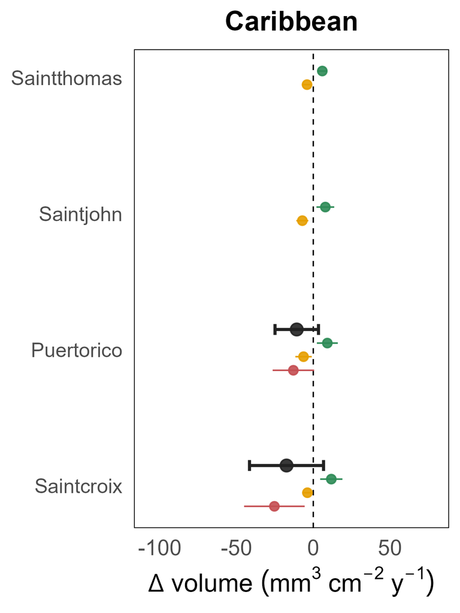

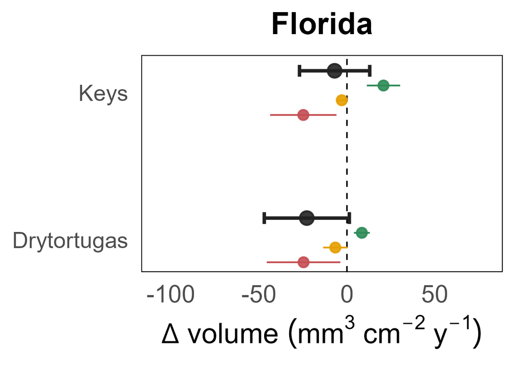

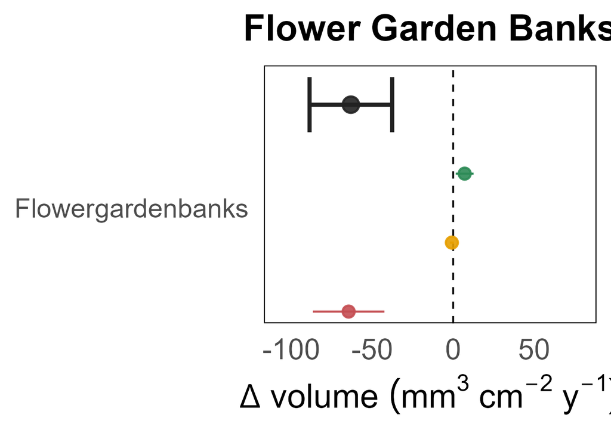

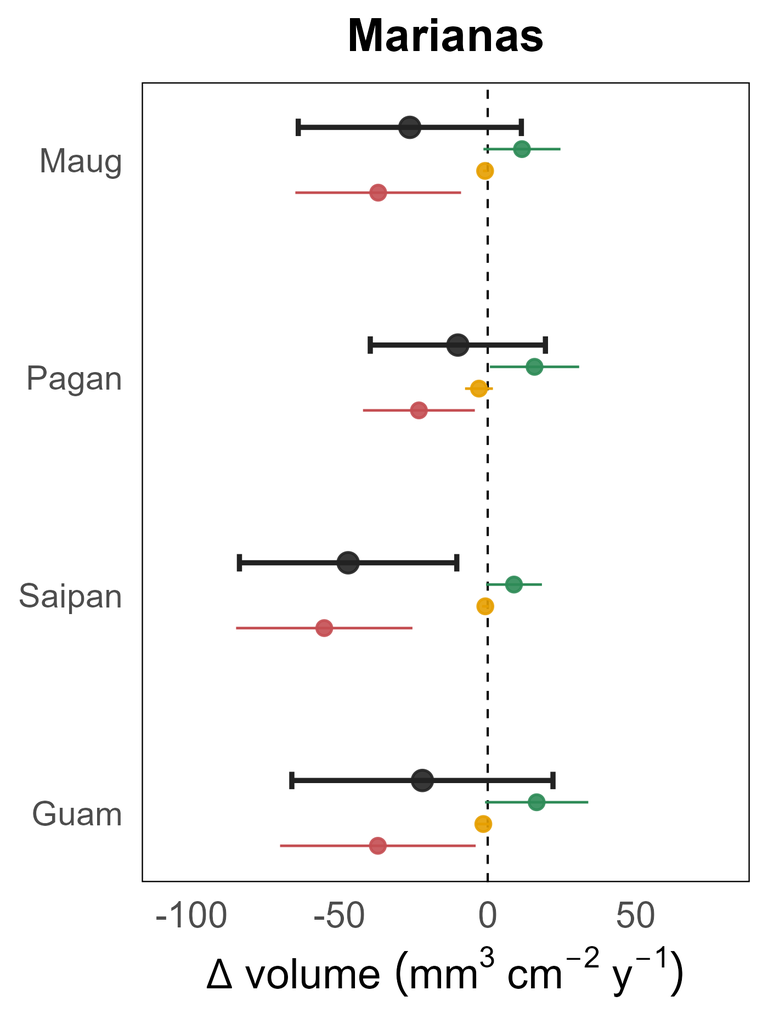

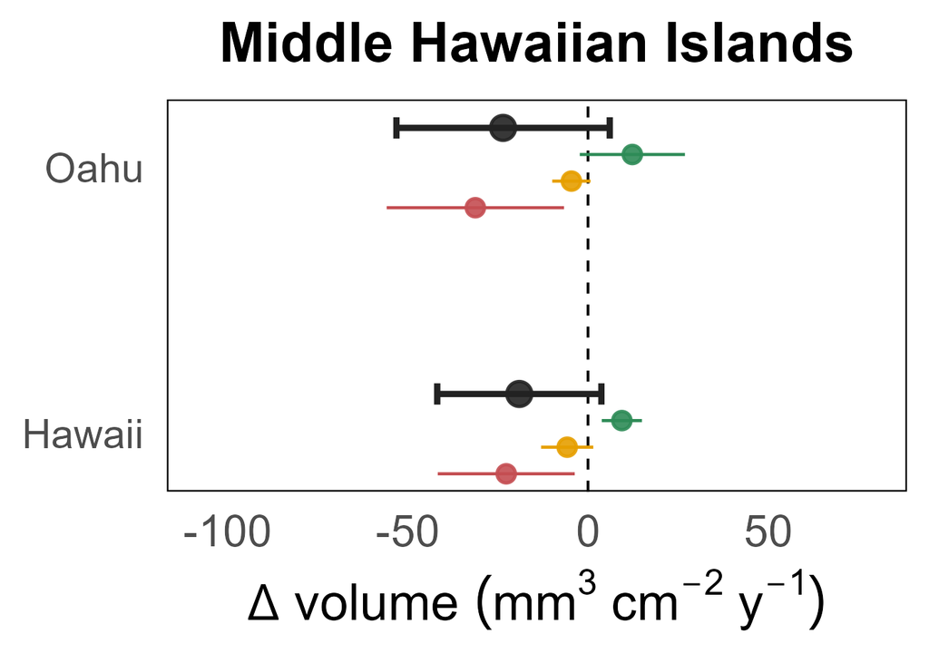

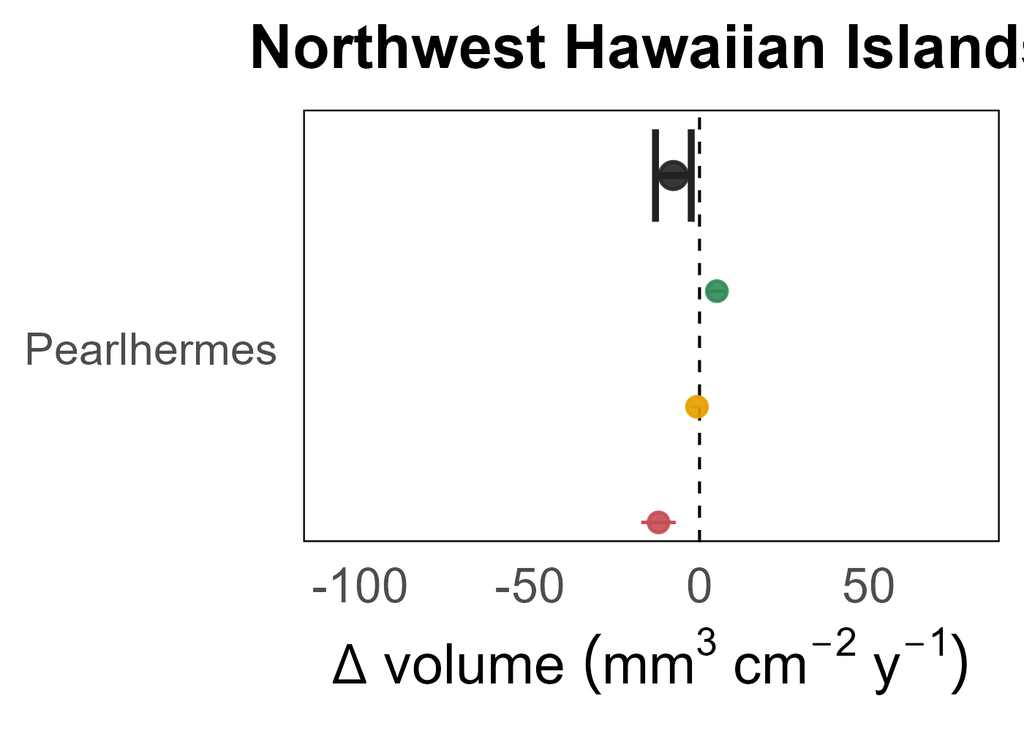

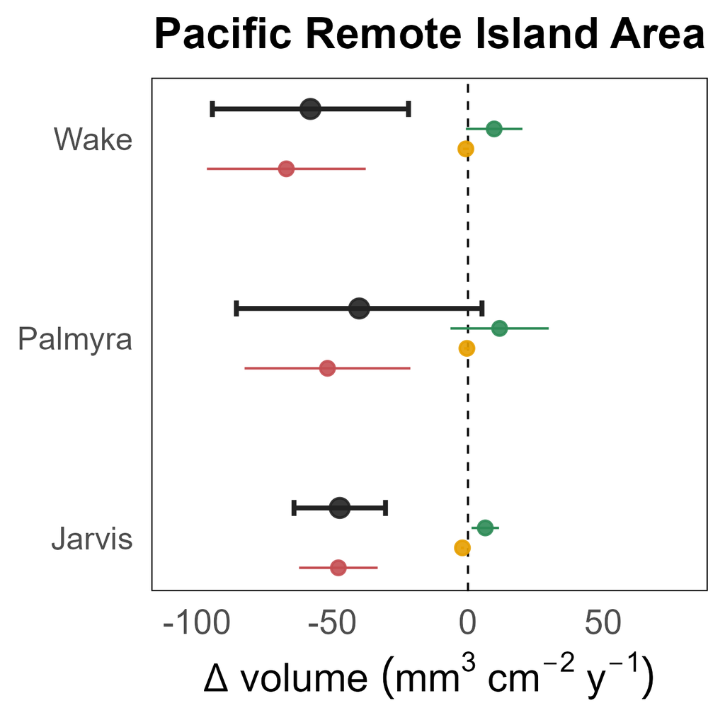

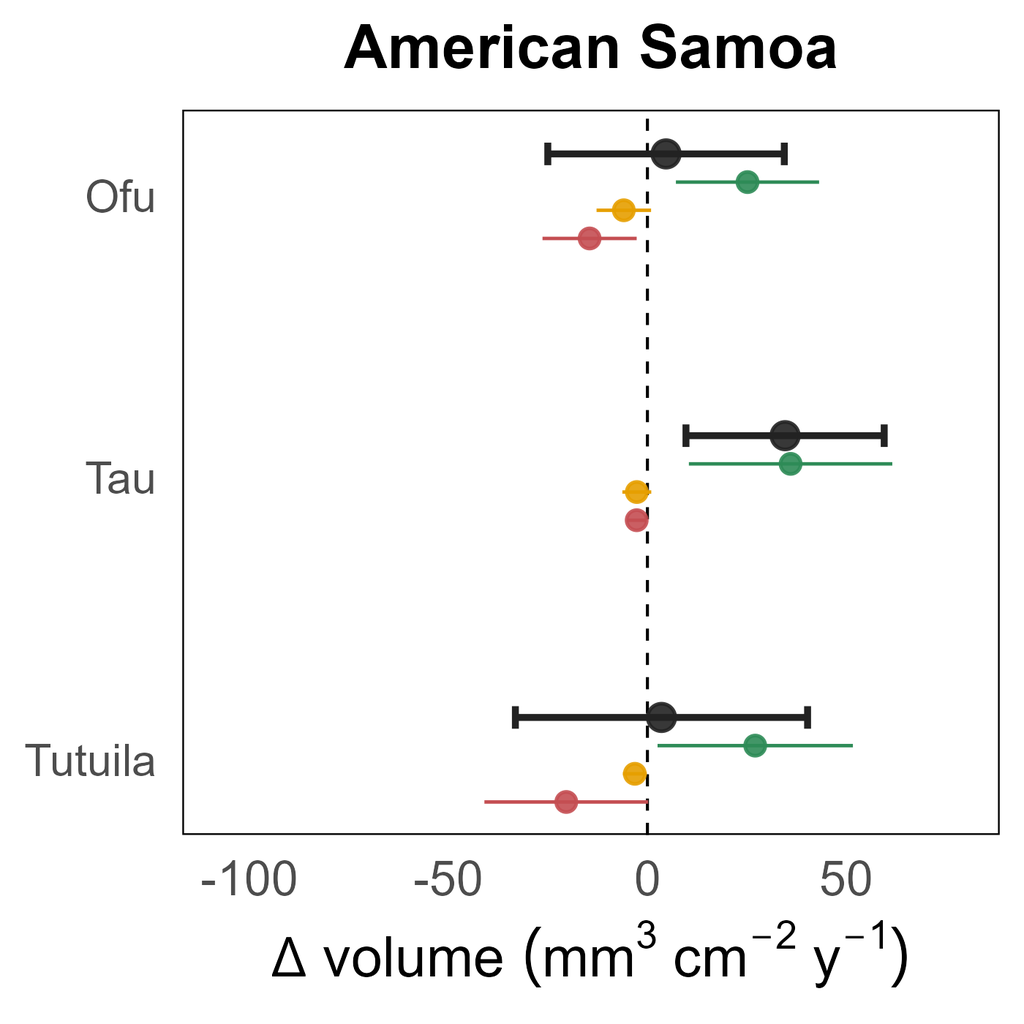

#Drivers of carbonate persistence: Data were analyzed using linear models. Separate models were constructed for each basin, at two spatial scales, island-level and site-level, depending on the spatial resolution of the predictor data. Response parameters (Δmass, Δvolume, Δdensity, accretion, grazing, and macroboring) were grouped at the appropriate scale, resulting in an island or site-specific mean, used in the subsequent analysis. Candidate predictors were first analyzed for collinearity and models were constructed to maintain adequate residual degrees of freedom, and avoid strongly collinear predictors.

The effects of parrotfish grazing pressure and urban influence were analyzed at the site scale, with depth included as covariate in the Pacific. In the Atlantic, only parrotfish grazing pressure was used as a predictor due to strong collinearity among predictors, partly reflecting the lower number of Atlantic sites relative to the Pacific (8 vs. 37; Table SX; Figure SXX). Environmental predictors were evaluated at the island level, with chlorophyll and aragonite saturation state considered in the Atlantic, and depth added to the two parameters in the Pacific. Temperature (satellite-derived) was not evaluated due to collinearity with aragonite saturation state and mean site depth in both basins.

## 3.1 Check collinearity among parrotfish pressure, Urban Influence, and depth

Collinearity among loc3-level predictors by Basin

| Basin | Predictor comparison | n | Correlation | p-value |
| --- | --- | --- | --- | --- |
| Atlantic | Parrotfish pressure vs. Depth | 8 | 0.714 | 4.67e-02 |
| Atlantic | Parrotfish pressure vs. Urban Influence | 8 | 0.972 | 5.15e-05 |
| Atlantic | Urban Influence vs. Depth | 8 | 0.590 | 1.24e-01 |
| Pacific | Parrotfish pressure vs. Depth | 37 | 0.166 | 3.25e-01 |
| Pacific | Parrotfish pressure vs. Urban Influence | 37 | 0.079 | 6.43e-01 |
| Pacific | Urban Influence vs. Depth | 37 | -0.119 | 4.84e-01 |

## 3.2 Analyze response variables at the loc3 level

Loc3-level analysis using existing combinedTableLoc3 Each loc3 row is one statistical replicate.

Separate models are run for Atlantic and Pacific. Atlantic: response ~ parrotfish pressure only Pacific: response ~ parrotfish pressure + urban influence + depth

Full loc3-level model coefficient table using combinedTableLoc3. Atlantic models include parrotfish pressure only. Pacific models include parrotfish pressure, urban influence, and depth.

| Response | Basin | N loc3 | N loc2 | N loc1 | R-squared | Adjusted R-squared | Term | Estimate | Std. Error | t value | p value |
| --- | --- | --- | --- | --- | --- | --- | --- | --- | --- | --- | --- |
| Mass (mg cm<sup>-2</sup> yr<sup>-1</sup>) | Atlantic | 8 | 4 | 3 | 0.7986 | 0.7650 | Intercept | 8.8914 | 6.5528 | 1.3569 | 0.2236 |
|  | Atlantic | 8 | 4 | 3 | 0.7986 | 0.7650 | Parrotfish pressure | -61.9720 | 12.7066 | -4.8772 | 0.0028 |
|  | Pacific | 37 | 13 | 5 | 0.2984 | 0.2346 | Intercept | 33.9763 | 64.1123 | 0.5299 | 0.5997 |
|  | Pacific | 37 | 13 | 5 | 0.2984 | 0.2346 | Parrotfish pressure | 9.5763 | 3.7835 | 2.5311 | 0.0163 |
|  | Pacific | 37 | 13 | 5 | 0.2984 | 0.2346 | Urban influence | -0.0290 | 0.0096 | -3.0020 | 0.0051 |
|  | Pacific | 37 | 13 | 5 | 0.2984 | 0.2346 | Depth | -3.6740 | 4.3985 | -0.8353 | 0.4096 |
| Volume (mm<sup>3</sup> cm<sup>-2</sup> yr<sup>-1</sup>) | Atlantic | 8 | 4 | 3 | 0.7809 | 0.7444 | Intercept | -3.9564 | 4.8390 | -0.8176 | 0.4448 |
|  | Atlantic | 8 | 4 | 3 | 0.7809 | 0.7444 | Parrotfish pressure | -43.3931 | 9.3833 | -4.6245 | 0.0036 |
|  | Pacific | 37 | 13 | 5 | 0.2610 | 0.1938 | Intercept | 14.9165 | 48.8422 | 0.3054 | 0.7620 |
|  | Pacific | 37 | 13 | 5 | 0.2610 | 0.1938 | Parrotfish pressure | 7.6631 | 2.8823 | 2.6587 | 0.0120 |
|  | Pacific | 37 | 13 | 5 | 0.2610 | 0.1938 | Urban influence | -0.0176 | 0.0073 | -2.3970 | 0.0223 |
|  | Pacific | 37 | 13 | 5 | 0.2610 | 0.1938 | Depth | -2.5818 | 3.3509 | -0.7705 | 0.4465 |
| Density (mg cm<sup>-3</sup>cm<sup>-2</sup> yr<sup>-1</sup>) | Atlantic | 8 | 4 | 3 | 0.6677 | 0.6123 | Intercept | 0.8741 | 0.0905 | 9.6576 | 0.0001 |
|  | Atlantic | 8 | 4 | 3 | 0.6677 | 0.6123 | Parrotfish pressure | 0.6094 | 0.1755 | 3.4724 | 0.0133 |
|  | Pacific | 31 | 12 | 5 | 0.1264 | 0.0293 | Intercept | 0.4075 | 1.7912 | 0.2275 | 0.8218 |
|  | Pacific | 31 | 12 | 5 | 0.1264 | 0.0293 | Parrotfish pressure | -0.2015 | 0.1027 | -1.9613 | 0.0602 |
|  | Pacific | 31 | 12 | 5 | 0.1264 | 0.0293 | Urban influence | 0.0000 | 0.0003 | 0.1490 | 0.8826 |
|  | Pacific | 31 | 12 | 5 | 0.1264 | 0.0293 | Depth | 0.0368 | 0.1240 | 0.2971 | 0.7687 |
| Accretion (mm<sup>3</sup> cm<sup>-2</sup> yr<sup>-1</sup>) | Atlantic | 8 | 4 | 3 | 0.0818 | -0.0712 | Intercept | 12.1212 | 2.8022 | 4.3257 | 0.0050 |
|  | Atlantic | 8 | 4 | 3 | 0.0818 | -0.0712 | Parrotfish pressure | -3.9723 | 5.4337 | -0.7311 | 0.4923 |
|  | Pacific | 37 | 13 | 5 | 0.2891 | 0.2244 | Intercept | 37.7614 | 17.2714 | 2.1863 | 0.0360 |
|  | Pacific | 37 | 13 | 5 | 0.2891 | 0.2244 | Parrotfish pressure | 3.0007 | 1.0192 | 2.9440 | 0.0059 |
|  | Pacific | 37 | 13 | 5 | 0.2891 | 0.2244 | Urban influence | -0.0062 | 0.0026 | -2.3880 | 0.0228 |
|  | Pacific | 37 | 13 | 5 | 0.2891 | 0.2244 | Depth | -1.5749 | 1.1849 | -1.3292 | 0.1929 |
| Grazing (mm<sup>3</sup> cm<sup>-2</sup> yr<sup>-1</sup>) | Atlantic | 8 | 4 | 3 | 0.7654 | 0.7263 | Intercept | -10.3126 | 5.0047 | -2.0606 | 0.0850 |
|  | Atlantic | 8 | 4 | 3 | 0.7654 | 0.7263 | Parrotfish pressure | -42.9340 | 9.7047 | -4.4240 | 0.0045 |
|  | Pacific | 37 | 13 | 5 | 0.2114 | 0.1397 | Intercept | -15.9956 | 38.1766 | -0.4190 | 0.6779 |
|  | Pacific | 37 | 13 | 5 | 0.2114 | 0.1397 | Parrotfish pressure | 4.9093 | 2.2529 | 2.1791 | 0.0366 |
|  | Pacific | 37 | 13 | 5 | 0.2114 | 0.1397 | Urban influence | -0.0128 | 0.0057 | -2.2289 | 0.0327 |
|  | Pacific | 37 | 13 | 5 | 0.2114 | 0.1397 | Depth | -1.3059 | 2.6191 | -0.4986 | 0.6214 |
| Macroboring (mm<sup>3</sup> cm<sup>-2</sup> yr<sup>-1</sup>) | Atlantic | 8 | 4 | 3 | 0.2471 | 0.1216 | Intercept | -5.7649 | 1.2913 | -4.4645 | 0.0043 |
|  | Atlantic | 8 | 4 | 3 | 0.2471 | 0.1216 | Parrotfish pressure | 3.5133 | 2.5039 | 1.4031 | 0.2102 |
|  | Pacific | 37 | 13 | 5 | 0.1646 | 0.0887 | Intercept | -6.8493 | 3.9873 | -1.7178 | 0.0952 |
|  | Pacific | 37 | 13 | 5 | 0.1646 | 0.0887 | Parrotfish pressure | -0.2468 | 0.2353 | -1.0491 | 0.3018 |
|  | Pacific | 37 | 13 | 5 | 0.1646 | 0.0887 | Urban influence | 0.0014 | 0.0006 | 2.3225 | 0.0265 |
|  | Pacific | 37 | 13 | 5 | 0.1646 | 0.0887 | Depth | 0.2991 | 0.2736 | 1.0933 | 0.2822 |

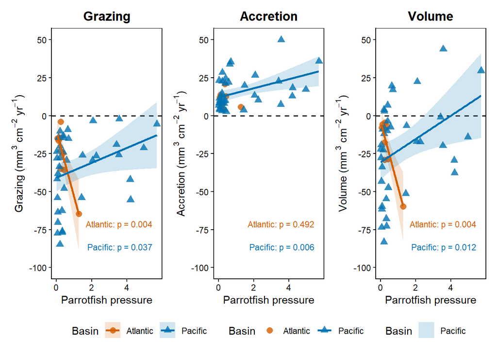

# 4 Run linear models for Loc2 site-level analysis

Note sites like St. Thomas and Wake with no density are not included in the analysis only of those parameters, as listed with NAs.

This is what ChatGPT told me about removing depth (don’t use): “Depth was not a predictor of interest, it did not improve interpretation, and including it costs degrees of freedom in a small loc2-level dataset.”

## 4.1 Are loc2 environmental predictors collinear?

Pairwise correlations among loc2-level environmental predictors.

| Basin | Comparison | n | Correlation | p value |
| --- | --- | --- | --- | --- |
| Atlantic | Chlorophyll vs. Depth | 5 | 0.110 | 0.860 |
| Pacific | Chlorophyll vs. Depth | 13 | -0.052 | 0.865 |
| Atlantic | Chlorophyll vs. Temperature | 5 | -0.103 | 0.868 |
| Pacific | Chlorophyll vs. Temperature | 13 | -0.232 | 0.446 |
| Atlantic | Omega vs. Chlorophyll | 5 | 0.064 | 0.919 |
| Pacific | Omega vs. Chlorophyll | 13 | -0.456 | 0.118 |
| Atlantic | Omega vs. Depth | 5 | 0.978 | 0.004 |
| Pacific | Omega vs. Depth | 13 | 0.413 | 0.161 |
| Atlantic | Omega vs. Temperature | 5 | -0.740 | 0.153 |
| Pacific | Omega vs. Temperature | 13 | 0.713 | 0.006 |
| Atlantic | Temperature vs. Depth | 5 | -0.717 | 0.173 |
| Pacific | Temperature vs. Depth | 13 | 0.534 | 0.060 |

## 4.2 Analyze response variables at the loc2 level

Full loc2-level model coefficient table using combinedTableLoc2. Atlantic models include omega and chlorophyll. Pacific models include omega, chlorophyll, and depth.

| Response | Basin | N loc2 | N loc1 | R-squared | Adjusted R-squared | Term | Estimate | Std. Error | t value | p value |
| --- | --- | --- | --- | --- | --- | --- | --- | --- | --- | --- |
| Mass (mg cm<sup>-2</sup> yr<sup>-1</sup>) | Atlantic | 5 | 3 | 0.9937 | 0.9873 | Intercept | 1102.6784 | 64.4118 | 17.1192 | 0.0034 |
|  | Atlantic | 5 | 3 | 0.9937 | 0.9873 | Omega | -292.5444 | 17.1088 | -17.0990 | 0.0034 |
|  | Atlantic | 5 | 3 | 0.9937 | 0.9873 | Chlorophyll | -101.5909 | 28.8969 | -3.5156 | 0.0722 |
|  | Pacific | 13 | 5 | 0.0934 | -0.2088 | Intercept | -193.2881 | 260.3043 | -0.7425 | 0.4767 |
|  | Pacific | 13 | 5 | 0.0934 | -0.2088 | Omega | 45.5847 | 71.3227 | 0.6391 | 0.5387 |
|  | Pacific | 13 | 5 | 0.0934 | -0.2088 | Chlorophyll | -57.9614 | 271.7777 | -0.2133 | 0.8359 |
|  | Pacific | 13 | 5 | 0.0934 | -0.2088 | Depth | 0.9082 | 14.1876 | 0.0640 | 0.9504 |
| Volume (mm<sup>3</sup> cm<sup>-2</sup> yr<sup>-1</sup>) | Atlantic | 4 | 3 | 0.9683 | 0.9050 | Intercept | 807.5058 | 150.5148 | 5.3650 | 0.1173 |
|  | Atlantic | 4 | 3 | 0.9683 | 0.9050 | Omega | -220.5793 | 40.1327 | -5.4962 | 0.1146 |
|  | Atlantic | 4 | 3 | 0.9683 | 0.9050 | Chlorophyll | -10.4135 | 67.4567 | -0.1544 | 0.9025 |
|  | Pacific | 13 | 5 | 0.1513 | -0.1316 | Intercept | -172.0737 | 197.7777 | -0.8700 | 0.4069 |
|  | Pacific | 13 | 5 | 0.1513 | -0.1316 | Omega | 50.6097 | 54.1905 | 0.9339 | 0.3747 |
|  | Pacific | 13 | 5 | 0.1513 | -0.1316 | Chlorophyll | -53.1547 | 206.4951 | -0.2574 | 0.8026 |
|  | Pacific | 13 | 5 | 0.1513 | -0.1316 | Depth | -1.8764 | 10.7796 | -0.1741 | 0.8657 |
| Density (mg cm<sup>-3</sup>) | Atlantic | 4 | 3 | 0.5815 | -0.2555 | Intercept | -5.8752 | 6.1837 | -0.9501 | 0.5163 |
|  | Atlantic | 4 | 3 | 0.5815 | -0.2555 | Omega | 1.8483 | 1.6488 | 1.1210 | 0.4637 |
|  | Atlantic | 4 | 3 | 0.5815 | -0.2555 | Chlorophyll | 0.7485 | 2.7713 | 0.2701 | 0.8321 |
|  | Pacific | 12 | 5 | 0.6958 | 0.5817 | Intercept | 11.5875 | 3.4336 | 3.3748 | 0.0097 |
|  | Pacific | 12 | 5 | 0.6958 | 0.5817 | Omega | -3.9113 | 0.9522 | -4.1078 | 0.0034 |
|  | Pacific | 12 | 5 | 0.6958 | 0.5817 | Chlorophyll | -10.2717 | 3.6516 | -2.8130 | 0.0227 |
|  | Pacific | 12 | 5 | 0.6958 | 0.5817 | Depth | 0.2962 | 0.1923 | 1.5401 | 0.1621 |
| Accretion (mm<sup>3</sup> cm<sup>-2</sup> yr<sup>-1</sup>) | Atlantic | 5 | 3 | 0.6023 | 0.2046 | Intercept | 170.6530 | 97.9604 | 1.7421 | 0.2236 |
|  | Atlantic | 5 | 3 | 0.6023 | 0.2046 | Omega | -40.5053 | 26.0199 | -1.5567 | 0.2598 |
|  | Atlantic | 5 | 3 | 0.6023 | 0.2046 | Chlorophyll | -29.7678 | 43.9477 | -0.6773 | 0.5680 |
|  | Pacific | 13 | 5 | 0.5107 | 0.3476 | Intercept | -113.7285 | 53.5499 | -2.1238 | 0.0627 |
|  | Pacific | 13 | 5 | 0.5107 | 0.3476 | Omega | 38.1818 | 14.6725 | 2.6023 | 0.0286 |
|  | Pacific | 13 | 5 | 0.5107 | 0.3476 | Chlorophyll | 8.6375 | 55.9103 | 0.1545 | 0.8806 |
|  | Pacific | 13 | 5 | 0.5107 | 0.3476 | Depth | -0.7548 | 2.9187 | -0.2586 | 0.8018 |
| Grazing (mm<sup>3</sup> cm<sup>-2</sup> yr<sup>-1</sup>) | Atlantic | 4 | 3 | 0.8551 | 0.5652 | Intercept | 631.3405 | 277.7392 | 2.2731 | 0.2638 |
|  | Atlantic | 4 | 3 | 0.8551 | 0.5652 | Omega | -179.3905 | 74.0554 | -2.4224 | 0.2492 |
|  | Atlantic | 4 | 3 | 0.8551 | 0.5652 | Chlorophyll | 47.1504 | 124.4752 | 0.3788 | 0.7695 |
|  | Pacific | 13 | 5 | 0.0228 | -0.3029 | Intercept | -50.2668 | 157.9418 | -0.3183 | 0.7575 |
|  | Pacific | 13 | 5 | 0.0228 | -0.3029 | Omega | 8.8453 | 43.2756 | 0.2044 | 0.8426 |
|  | Pacific | 13 | 5 | 0.0228 | -0.3029 | Chlorophyll | -43.2897 | 164.9034 | -0.2625 | 0.7988 |
|  | Pacific | 13 | 5 | 0.0228 | -0.3029 | Depth | -0.7275 | 8.6084 | -0.0845 | 0.9345 |
| Macroboring (mm<sup>3</sup> cm<sup>-2</sup> yr<sup>-1</sup>) | Atlantic | 5 | 3 | 0.5843 | 0.1686 | Intercept | -50.0611 | 33.9305 | -1.4754 | 0.2781 |
|  | Atlantic | 5 | 3 | 0.5843 | 0.1686 | Omega | 13.2059 | 9.0125 | 1.4653 | 0.2805 |
|  | Atlantic | 5 | 3 | 0.5843 | 0.1686 | Chlorophyll | -13.8044 | 15.2221 | -0.9069 | 0.4602 |
|  | Pacific | 13 | 5 | 0.0012 | -0.3318 | Intercept | -2.7029 | 16.2718 | -0.1661 | 0.8717 |
|  | Pacific | 13 | 5 | 0.0012 | -0.3318 | Omega | 0.1172 | 4.4584 | 0.0263 | 0.9796 |
|  | Pacific | 13 | 5 | 0.0012 | -0.3318 | Chlorophyll | -1.2670 | 16.9890 | -0.0746 | 0.9422 |
|  | Pacific | 13 | 5 | 0.0012 | -0.3318 | Depth | -0.0060 | 0.8869 | -0.0068 | 0.9947 |